# CS534 Final Report

Predicting Patient Length of Stay and Cost per Day

Courtney Gale & Randy Parrish

12/04/2020

# 1 Introduction

Predicting patient outcomes early in the admission process is an important part of hospital management [1,2]. Estimating a patient’s length of stay, for instance, assists in logistics such as allocation of hospital resources [2]. The ability to predict patient-specific healthcare costs helps us gain understanding of the situations that lead to high healthcare costs and can inform future decisions in preventative care, which has been shown to be one of the best ways to decrease healthcare cost [3].

For our final project we will be using the Statewide Planning and Research Cooperative System (SPARCS) Inpatient De-identified File dataset (originally provided the New York State Department of Health [4]) as it appears on Kaggle [5] to predict length of stay (LOS) in days, a metric used to assess hospital efficiency and quality of care [2,6,7], and patient cost per day. The full dataset contains nearly 2.35 million de-identified observations and 37 features about hospital inpatient discharge data for 2015.

# 2 Set Up

## 2.1 Libraries

```r
library(ggplot2)
library(ggiraph)
library(htmlwidgets)
library(kableExtra)
library(lme4)
library(spaMM)
spaMM.options(nb_cores = future::availableCores() - 1)
```

## 2.2 Miscellaneous Functions

```r
report_table <- function(x, w = NULL, h = "500px", ec = NULL, rownames = FALSE, scroll = TRUE) {
    y <- kable_paper(kable_styling(kbl(x, row.names = rownames), full_width = T,
        position = "center", bootstrap_options = c("striped", "hover"), fixed_thead = T),
        full_width = T)

    if (scroll) {
        y <- scroll_box(y, fixed_thead = T, height = h, width = w, extra_css = ec)
    }
    y
}

report_plot <- function(x) {
    girafe_options(girafe(code = print(x)), opts_sizing(rescale = TRUE), opts_tooltip(opacity = 0.9,
        css = "background-color:gray;color:white;padding:2px;border-radius:2px;"),
        opts_hover(css = "cursor:pointer;"), sizingPolicy(defaultWidth = "100%",
            defaultHeight = "300px"))
}
```

## 2.3 Data Import

```r
# Import the data
dat <- read.csv("input/Hospital_Inpatient_Discharges__SPARCS_De-Identified___2015.csv",
    colClasses = c(rep("factor", 10), "character", rep("factor", 21), "numeric",
        rep("factor", 2), rep("character", 2)), na.strings = c("NA", ""))
```

In addition to the columns found in the Kaggle dataset [5], we will also be using the New York State Department of Health’s “Health Facility General Information” dataset [8] in order to incorporate `Facility.Type` and `Ownership.Type` variables into our analysis by matching on `Facility.ID`.

```r
# read in facility id and description columns from facility information dataset
dat_hf <- read.csv("input/Health_Facility_General_Information.csv", colClasses = c("factor",
    rep("NULL", 2), "character", rep("NULL", 28), "character", rep("NULL", 3)), skipNul = TRUE)

# remove duplicate rows
dat_hf <- dat_hf[!duplicated(dat_hf), ]

# rename columns
colnames(dat_hf) <- c("Facility.Id", "Facility.Type", "Ownership.Type")

# merge datasets by Facility Id
dat <- droplevels(merge(dat, dat_hf, by = "Facility.Id", all.x = TRUE, sort = FALSE))
```

```r
report_table(head(dat, 50))
```

| Facility.Id | Health.Service.Area | Hospital.County | Operating.Certificate.Number | Facility.Name | Age.Group | Zip.Code…3.digits | Gender | Race | Ethnicity | Length.of.Stay | Type.of.Admission | Patient.Disposition | Discharge.Year | CCS.Diagnosis.Code | CCS.Diagnosis.Description | CCS.Procedure.Code | CCS.Procedure.Description | APR.DRG.Code | APR.DRG.Description | APR.MDC.Code | APR.MDC.Description | APR.Severity.of.Illness.Code | APR.Severity.of.Illness.Description | APR.Risk.of.Mortality | APR.Medical.Surgical.Description | Payment.Typology.1 | Payment.Typology.2 | Payment.Typology.3 | Attending.Provider.License.Number | … |
| --- | --- | --- | --- | --- | --- | --- | --- | --- | --- | --- | --- | --- | --- | --- | --- | --- | --- | --- | --- | --- | --- | --- | --- | --- | --- | --- | --- | --- | --- | --- |
| 66 | Western NY | Cattaraugus | 0401001 | Olean General Hospital | 30 to 49 | 147 | F | White | Not Span/Hispanic | 5 | Emergency | Home or Self Care | 2015 | 127 | Chronic obstructive pulmonary disease and bronchiectasis | 0 | NO PROC | 140 | Chronic obstructive pulmonary disease | 4 | Diseases and Disorders of the Respiratory System | 3 | Major | Moderate | Medical | Medicare | Medicaid | NA | 197453 | … |
| 66 | Western NY | Cattaraugus | 0401001 | Olean General Hospital | 70 or Older | 147 | M | White | Not Span/Hispanic | 3 | Emergency | Home w/ Home Health Services | 2015 | 108 | Congestive heart failure; nonhypertensive | 58 | HEMODIALYSIS | 194 | Heart failure | 5 | Diseases and Disorders of the Circulatory System | 3 | Major | Major | Medical | Medicare | NA | NA | 40003993 | … |
| 66 | Western NY | Cattaraugus | 0401001 | Olean General Hospital | 70 or Older | 148 | F | White | Not Span/Hispanic | 9 | Emergency | Home or Self Care | 2015 | 2 | Septicemia (except in labor) | 222 | BLOOD TRANSFUSION | 720 | Septicemia & disseminated infections | 18 | Infectious and Parasitic Diseases, Systemic or Unspecified Sites | 4 | Extreme | Major | Medical | Medicare | NA | NA | 266409 | … |
| 66 | Western NY | Cattaraugus | 0401001 | Olean General Hospital | 50 to 69 | OOS | F | White | Not Span/Hispanic | 2 | Elective | Home or Self Care | 2015 | 100 | Acute myocardial infarction | 47 | DX CARDIAC CATHETERIZTN | 190 | Acute myocardial infarction | 5 | Diseases and Disorders of the Circulatory System | 2 | Moderate | Moderate | Medical | Medicaid | NA | NA | 90271326 | … |
| 66 | Western NY | Cattaraugus | 0401001 | Olean General Hospital | 70 or Older | 147 | F | White | Not Span/Hispanic | 4 | Emergency | Home w/ Home Health Services | 2015 | 100 | Acute myocardial infarction | 0 | NO PROC | 190 | Acute myocardial infarction | 5 | Diseases and Disorders of the Circulatory System | 2 | Moderate | Moderate | Medical | Medicare | NA | NA | 266141 | … |
| 66 | Western NY | Cattaraugus | 0401001 | Olean General Hospital | 18 to 29 | 141 | M | White | Not Span/Hispanic | 7 | Emergency | Short-term Hospital | 2015 | 130 | Pleurisy; pneumothorax; pulmonary collapse | 39 | INCISION OF PLEURA | 143 | Other respiratory diagnoses except signs, symptoms & minor diagnoses | 4 | Diseases and Disorders of the Respiratory System | 1 | Minor | Minor | Medical | Medicaid | NA | NA | 271326 | … |
| 66 | Western NY | Cattaraugus | 0401001 | Olean General Hospital | 50 to 69 | 141 | M | White | Not Span/Hispanic | 9 | Emergency | Home w/ Home Health Services | 2015 | 660 | Alcohol-related disorders | 231 | OTHER THERAPEUTIC PRCS | 280 | Alcoholic liver disease | 7 | Diseases and Disorders of the Hepatobiliary System and Pancreas | 3 | Major | Major | Medical | Medicare | NA | NA | 40003993 | … |
| 66 | Western NY | Cattaraugus | 0401001 | Olean General Hospital | 0 to 17 | 147 | F | White | Not Span/Hispanic | 3 | Newborn | Home or Self Care | 2015 | 218 | Liveborn | 0 | NO PROC | 640 | Neonate birthwt >2499g, normal newborn or neonate w other problem | 15 | Newborns and Other Neonates with Conditions Originating in the Perinatal Period | 1 | Minor | Minor | Medical | Medicaid | NA | NA | 256322 | … |
| 66 | Western NY | Cattaraugus | 0401001 | Olean General Hospital | 0 to 17 | 147 | F | White | Not Span/Hispanic | 4 | Newborn | Home or Self Care | 2015 | 218 | Liveborn | 0 | NO PROC | 640 | Neonate birthwt >2499g, normal newborn or neonate w other problem | 15 | Newborns and Other Neonates with Conditions Originating in the Perinatal Period | 2 | Moderate | Minor | Medical | Medicaid | NA | NA | 182357 | … |
| 66 | Western NY | Cattaraugus | 0401001 | Olean General Hospital | 70 or Older | 147 | F | White | Not Span/Hispanic | 4 | Elective | Skilled Nursing Home | 2015 | 204 | Other non-traumatic joint disorders | 152 | ARTHROPLASTY KNEE | 302 | Knee joint replacement | 8 | Diseases and Disorders of the Musculoskeletal System and Conn Tissue | 1 | Minor | Minor | Surgical | Medicare | Private Health Insurance | NA | 257934 | … |
| 66 | Western NY | Cattaraugus | 0401001 | Olean General Hospital | 0 to 17 | 147 | F | White | Not Span/Hispanic | 1 | Newborn | Home or Self Care | 2015 | 218 | Liveborn | 0 | NO PROC | 640 | Neonate birthwt >2499g, normal newborn or neonate w other problem | 15 | Newborns and Other Neonates with Conditions Originating in the Perinatal Period | 1 | Minor | Minor | Medical | Medicaid | NA | NA | 231077 | … |
| 66 | Western NY | Cattaraugus | 0401001 | Olean General Hospital | 50 to 69 | 140 | M | White | Not Span/Hispanic | 4 | Emergency | Home or Self Care | 2015 | 2 | Septicemia (except in labor) | 0 | NO PROC | 720 | Septicemia & disseminated infections | 18 | Infectious and Parasitic Diseases, Systemic or Unspecified Sites | 3 | Major | Major | Medical | Medicare | Blue Cross/Blue Shield | NA | 271326 | … |
| 66 | Western NY | Cattaraugus | 0401001 | Olean General Hospital | 0 to 17 | 147 | M | White | Not Span/Hispanic | 2 | Newborn | Home or Self Care | 2015 | 218 | Liveborn | 115 | CIRCUMCISION | 640 | Neonate birthwt >2499g, normal newborn or neonate w other problem | 15 | Newborns and Other Neonates with Conditions Originating in the Perinatal Period | 1 | Minor | Minor | Medical | Medicaid | NA | NA | 231077 | … |
| 66 | Western NY | Cattaraugus | 0401001 | Olean General Hospital | 50 to 69 | 147 | M | White | Not Span/Hispanic | 2 | Emergency | Home or Self Care | 2015 | 129 | Aspiration pneumonitis; food/vomitus | 0 | NO PROC | 137 | Major respiratory infections & inflammations | 4 | Diseases and Disorders of the Respiratory System | 3 | Major | Moderate | Medical | Medicaid | NA | NA | 266141 | … |
| 66 | Western NY | Cattaraugus | 0401001 | Olean General Hospital | 0 to 17 | 147 | F | White | Not Span/Hispanic | 2 | Newborn | Home or Self Care | 2015 | 218 | Liveborn | 0 | NO PROC | 640 | Neonate birthwt >2499g, normal newborn or neonate w other problem | 15 | Newborns and Other Neonates with Conditions Originating in the Perinatal Period | 2 | Moderate | Minor | Medical | Medicaid | NA | NA | 237701 | … |
| 66 | Western NY | Cattaraugus | 0401001 | Olean General Hospital | 0 to 17 | 148 | M | White | Not Span/Hispanic | 1 | Newborn | Home or Self Care | 2015 | 218 | Liveborn | 115 | CIRCUMCISION | 640 | Neonate birthwt >2499g, normal newborn or neonate w other problem | 15 | Newborns and Other Neonates with Conditions Originating in the Perinatal Period | 1 | Minor | Minor | Medical | Medicaid | Medicaid | NA | 237701 | … |
| 66 | Western NY | Cattaraugus | 0401001 | Olean General Hospital | 18 to 29 | 147 | F | White | Not Span/Hispanic | 3 | Elective | Home or Self Care | 2015 | 187 | Malposition; malpresentation | 134 | CESAREAN SECTION | 540 | Cesarean delivery | 14 | Pregnancy, Childbirth and the Puerperium | 1 | Minor | Minor | Surgical | Medicaid | NA | NA | 147483 | … |
| 66 | Western NY | Cattaraugus | 0401001 | Olean General Hospital | 70 or Older | 147 | F | White | Not Span/Hispanic | 10 | Emergency | Inpatient Rehabilitation Facility | 2015 | 51 | Other endocrine disorders | 0 | NO PROC | 424 | Other endocrine disorders | 10 | Endocrine, Nutritional and Metabolic Diseases and Disorders | 3 | Major | Major | Medical | Medicare | NA | NA | 40003993 | … |
| 66 | Western NY | Cattaraugus | 0401001 | Olean General Hospital | 50 to 69 | 147 | F | White | Not Span/Hispanic | 13 | Emergency | Skilled Nursing Home | 2015 | 2 | Septicemia (except in labor) | 54 | OT VASC CATH; NOT HEART | 720 | Septicemia & disseminated infections | 18 | Infectious and Parasitic Diseases, Systemic or Unspecified Sites | 4 | Extreme | Extreme | Medical | Medicare | Private Health Insurance | NA | 197563 | … |
| 66 | Western NY | Cattaraugus | 0401001 | Olean General Hospital | 70 or Older | OOS | F | White | Not Span/Hispanic | 7 | Emergency | Home w/ Home Health Services | 2015 | 127 | Chronic obstructive pulmonary disease and bronchiectasis | 0 | NO PROC | 140 | Chronic obstructive pulmonary disease | 4 | Diseases and Disorders of the Respiratory System | 2 | Moderate | Moderate | Medical | Medicare | Federal/State/Local/VA | NA | 271326 | … |
| 66 | Western NY | Cattaraugus | 0401001 | Olean General Hospital | 50 to 69 | 147 | M | White | Not Span/Hispanic | 2 | Emergency | Home or Self Care | 2015 | 103 | Pulmonary heart disease | 0 | NO PROC | 134 | Pulmonary embolism | 4 | Diseases and Disorders of the Respiratory System | 1 | Minor | Minor | Medical | Medicaid | NA | NA | 271326 | … |
| 66 | Western NY | Cattaraugus | 0401001 | Olean General Hospital | 30 to 49 | 147 | F | White | Not Span/Hispanic | 7 | Emergency | Home or Self Care | 2015 | 657 | Mood disorders | 0 | NO PROC | 753 | Bipolar disorders | 19 | Mental Diseases and Disorders | 2 | Moderate | Minor | Medical | Medicaid | NA | NA | 40003856 | … |
| 66 | Western NY | Cattaraugus | 0401001 | Olean General Hospital | 0 to 17 | 147 | M | White | Not Span/Hispanic | 3 | Newborn | Home or Self Care | 2015 | 218 | Liveborn | 115 | CIRCUMCISION | 640 | Neonate birthwt >2499g, normal newborn or neonate w other problem | 15 | Newborns and Other Neonates with Conditions Originating in the Perinatal Period | 1 | Minor | Minor | Medical | Blue Cross/Blue Shield | NA | NA | 182357 | … |
| 66 | Western NY | Cattaraugus | 0401001 | Olean General Hospital | 50 to 69 | 147 | M | White | Not Span/Hispanic | 4 | Emergency | Home w/ Home Health Services | 2015 | 11 | Cancer of head and neck | 71 | GASTROSTOMY; TEMP/PERM | 110 | Ear, nose, mouth, throat, cranial/facial malignancies | 3 | Ear, Nose, Mouth, Throat and Craniofacial Diseases and Disorders | 3 | Major | Moderate | Medical | Private Health Insurance | Federal/State/Local/VA | NA | 256322 | … |
| 66 | Western NY | Cattaraugus | 0401001 | Olean General Hospital | 70 or Older | 148 | M | White | Not Span/Hispanic | 6 | Emergency | Skilled Nursing Home | 2015 | 50 | Diabetes mellitus with complications | 0 | NO PROC | 468 | Other kidney & urinary tract diagnoses, signs & symptoms | 11 | Diseases and Disorders of the Kidney and Urinary Tract | 3 | Major | Major | Medical | Medicare | Private Health Insurance | NA | 276511 | … |
| 66 | Western NY | Cattaraugus | 0401001 | Olean General Hospital | 50 to 69 | 147 | F | White | Not Span/Hispanic | 4 | Emergency | Home or Self Care | 2015 | 127 | Chronic obstructive pulmonary disease and bronchiectasis | 216 | RESP INTUB/MECH VENTIL | 140 | Chronic obstructive pulmonary disease | 4 | Diseases and Disorders of the Respiratory System | 3 | Major | Extreme | Medical | Medicare | NA | NA | 165169 | … |
| 66 | Western NY | Cattaraugus | 0401001 | Olean General Hospital | 0 to 17 | 141 | F | White | Not Span/Hispanic | 2 | Newborn | Home or Self Care | 2015 | 218 | Liveborn | 0 | NO PROC | 640 | Neonate birthwt >2499g, normal newborn or neonate w other problem | 15 | Newborns and Other Neonates with Conditions Originating in the Perinatal Period | 1 | Minor | Minor | Medical | Blue Cross/Blue Shield | NA | NA | 182357 | … |
| 66 | Western NY | Cattaraugus | 0401001 | Olean General Hospital | 30 to 49 | 148 | F | White | Not Span/Hispanic | 2 | Emergency | Home or Self Care | 2015 | 657 | Mood disorders | 0 | NO PROC | 753 | Bipolar disorders | 19 | Mental Diseases and Disorders | 1 | Minor | Minor | Medical | Federal/State/Local/VA | NA | NA | 267162 | … |
| 66 | Western NY | Cattaraugus | 0401001 | Olean General Hospital | 30 to 49 | 147 | F | White | Not Span/Hispanic | 1 | Elective | Home or Self Care | 2015 | 196 | Other pregnancy and delivery including normal | 137 | OT PRCS TO ASSIST DELIV | 541 | Vaginal delivery w sterilization &/or D&C | 14 | Pregnancy, Childbirth and the Puerperium | 1 | Minor | Minor | Surgical | Federal/State/Local/VA | NA | NA | 197563 | … |
| 66 | Western NY | Cattaraugus | 0401001 | Olean General Hospital | 18 to 29 | 147 | M | White | Not Span/Hispanic | 5 | Emergency | Home or Self Care | 2015 | 657 | Mood disorders | 0 | NO PROC | 751 | Major depressive disorders & other/unspecified psychoses | 19 | Mental Diseases and Disorders | 1 | Minor | Minor | Medical | Blue Cross/Blue Shield | Medicaid | NA | 267162 | … |
| 66 | Western NY | Cattaraugus | 0401001 | Olean General Hospital | 50 to 69 | 147 | F | White | Not Span/Hispanic | 9 | Emergency | Skilled Nursing Home | 2015 | 42 | Secondary malignancies | 231 | OTHER THERAPEUTIC PRCS | 952 | Nonextensive procedure unrelated to principal diagnosis | 4 | Diseases and Disorders of the Respiratory System | 3 | Major | Major | Surgical | Medicare | Medicaid | NA | 271326 | … |
| 66 | Western NY | Cattaraugus | 0401001 | Olean General Hospital | 50 to 69 | 147 | F | White | Not Span/Hispanic | 2 | Emergency | Home w/ Home Health Services | 2015 | 127 | Chronic obstructive pulmonary disease and bronchiectasis | 0 | NO PROC | 140 | Chronic obstructive pulmonary disease | 4 | Diseases and Disorders of the Respiratory System | 2 | Moderate | Moderate | Medical | Medicare | NA | NA | 271326 | … |
| 66 | Western NY | Cattaraugus | 0401001 | Olean General Hospital | 70 or Older | 147 | M | White | Not Span/Hispanic | 3 | Emergency | Home or Self Care | 2015 | 62 | Coagulation and hemorrhagic disorders | 76 | COLONOSCOPY AND BIOPSY | 661 | Coagulation & platelet disorders | 16 | Diseases and Disorders of Blood, Blood Forming Organs and Immunological Disorders | 3 | Major | Moderate | Medical | Medicare | NA | NA | 40003993 | … |
| 66 | Western NY | Cattaraugus | 0401001 | Olean General Hospital | 50 to 69 | 147 | F | White | Not Span/Hispanic | 6 | Emergency | Inpatient Rehabilitation Facility | 2015 | 135 | Intestinal infection | 222 | BLOOD TRANSFUSION | 248 | Major gastrointestinal & peritoneal infections | 6 | Diseases and Disorders of the Digestive System | 4 | Extreme | Major | Medical | Medicare | Medicaid | NA | 266141 | … |
| 66 | Western NY | Cattaraugus | 0401001 | Olean General Hospital | 70 or Older | 147 | F | White | Not Span/Hispanic | 10 | Emergency | Skilled Nursing Home | 2015 | 157 | Acute and unspecified renal failure | 222 | BLOOD TRANSFUSION | 460 | RENAL FAILURE | 11 | Diseases and Disorders of the Kidney and Urinary Tract | 4 | Extreme | Extreme | Medical | Medicare | Private Health Insurance | NA | 266141 | … |
| 66 | Western NY | Cattaraugus | 0401001 | Olean General Hospital | 18 to 29 | 147 | F | White | Not Span/Hispanic | 1 | Emergency | Left Against Medical Advice | 2015 | 196 | Other pregnancy and delivery including normal | 0 | NO PROC | 561 | Postpartum & post abortion diagnoses w/o procedure | 14 | Pregnancy, Childbirth and the Puerperium | 1 | Minor | Minor | Medical | Private Health Insurance | NA | NA | 256322 | … |
| 66 | Western NY | Cattaraugus | 0401001 | Olean General Hospital | 70 or Older | 140 | F | White | Not Span/Hispanic | 6 | Emergency | Skilled Nursing Home | 2015 | 159 | Urinary tract infections | 0 | NO PROC | 463 | Kidney & urinary tract infections | 11 | Diseases and Disorders of the Kidney and Urinary Tract | 3 | Major | Major | Medical | Medicare | NA | NA | 170599 | … |
| 66 | Western NY | Cattaraugus | 0401001 | Olean General Hospital | 50 to 69 | 147 | F | White | Not Span/Hispanic | 2 | Elective | Home or Self Care | 2015 | 44 | Neoplasms of unspecified nature or uncertain behavior | 124 | HYSTERECTOMY; AB/VAG | 513 | Uterine & adnexa procedures for non-malignancy except leiomyoma | 13 | Diseases and Disorders of the Female Reproductive System | 1 | Minor | Minor | Surgical | Blue Cross/Blue Shield | NA | NA | 155651 | … |
| 66 | Western NY | Cattaraugus | 0401001 | Olean General Hospital | 70 or Older | 147 | F | White | Not Span/Hispanic | 6 | Emergency | Home w/ Home Health Services | 2015 | 159 | Urinary tract infections | 54 | OT VASC CATH; NOT HEART | 463 | Kidney & urinary tract infections | 11 | Diseases and Disorders of the Kidney and Urinary Tract | 2 | Moderate | Major | Medical | Medicare | NA | NA | 161469 | … |
| 66 | Western NY | Cattaraugus | 0401001 | Olean General Hospital | 30 to 49 | 147 | F | White | Not Span/Hispanic | 2 | Emergency | Inpatient Rehabilitation Facility | 2015 | 3 | Bacterial infection; unspecified site | 54 | OT VASC CATH; NOT HEART | 724 | Other infectious & parasitic diseases | 18 | Infectious and Parasitic Diseases, Systemic or Unspecified Sites | 3 | Major | Minor | Medical | Medicaid | NA | NA | 197563 | … |
| 66 | Western NY | Cattaraugus | 0401001 | Olean General Hospital | 50 to 69 | 147 | F | White | Not Span/Hispanic | 6 | Elective | Home w/ Home Health Services | 2015 | 197 | Skin and subcutaneous tissue infections | 0 | NO PROC | 383 | Cellulitis & other skin infections | 9 | Diseases and Disorders of the Skin, Subcutaneous Tissue and Breast | 2 | Moderate | Minor | Medical | Medicare | NA | NA | 161469 | … |
| 66 | Western NY | Cattaraugus | 0401001 | Olean General Hospital | 50 to 69 | 141 | F | White | Not Span/Hispanic | 3 | Emergency | Home or Self Care | 2015 | 657 | Mood disorders | 0 | NO PROC | 751 | Major depressive disorders & other/unspecified psychoses | 19 | Mental Diseases and Disorders | 2 | Moderate | Minor | Medical | Blue Cross/Blue Shield | NA | NA | 275408 | … |
| 66 | Western NY | Cattaraugus | 0401001 | Olean General Hospital | 70 or Older | 147 | F | White | Not Span/Hispanic | 4 | Emergency | Skilled Nursing Home | 2015 | 153 | Gastrointestinal hemorrhage | 92 | OTHER BOWEL DX PRCS | 253 | Other & unspecified gastrointestinal hemorrhage | 6 | Diseases and Disorders of the Digestive System | 3 | Major | Extreme | Medical | Medicare | Medicaid | NA | 141658 | … |
| 66 | Western NY | Cattaraugus | 0401001 | Olean General Hospital | 50 to 69 | 148 | F | White | Not Span/Hispanic | 6 | Emergency | Hosp Basd Medicare Approved Swing Bed | 2015 | 197 | Skin and subcutaneous tissue infections | 54 | OT VASC CATH; NOT HEART | 383 | Cellulitis & other skin infections | 9 | Diseases and Disorders of the Skin, Subcutaneous Tissue and Breast | 1 | Minor | Moderate | Medical | Blue Cross/Blue Shield | NA | NA | 266141 | … |
| 66 | Western NY | Cattaraugus | 0401001 | Olean General Hospital | 50 to 69 | 147 | F | White | Not Span/Hispanic | 2 | Emergency | Home or Self Care | 2015 | 153 | Gastrointestinal hemorrhage | 92 | OTHER BOWEL DX PRCS | 253 | Other & unspecified gastrointestinal hemorrhage | 6 | Diseases and Disorders of the Digestive System | 1 | Minor | Minor | Medical | Blue Cross/Blue Shield | NA | NA | 256322 | … |
| 66 | Western NY | Cattaraugus | 0401001 | Olean General Hospital | 18 to 29 | 147 | F | White | Not Span/Hispanic | 3 | Elective | Home or Self Care | 2015 | 184 | Early or threatened labor | 137 | OT PRCS TO ASSIST DELIV | 560 | Vaginal delivery | 14 | Pregnancy, Childbirth and the Puerperium | 2 | Moderate | Minor | Medical | Medicaid | NA | NA | 60420192 | … |
| 66 | Western NY | Cattaraugus | 0401001 | Olean General Hospital | 70 or Older | 147 | M | White | Not Span/Hispanic | 2 | Emergency | Home or Self Care | 2015 | 146 | Diverticulosis and diverticulitis | 0 | NO PROC | 244 | Diverticulitis & diverticulosis | 6 | Diseases and Disorders of the Digestive System | 2 | Moderate | Moderate | Medical | Medicare | Blue Cross/Blue Shield | Private Health Insurance | 197453 | … |
| 66 | Western NY | Cattaraugus | 0401001 | Olean General Hospital | 50 to 69 | OOS | M | White | Not Span/Hispanic | 2 | Elective | Short-term Hospital | 2015 | 100 | Acute myocardial infarction | 47 | DX CARDIAC CATHETERIZTN | 190 | Acute myocardial infarction | 5 | Diseases and Disorders of the Circulatory System | 1 | Minor | Minor | Medical | Blue Cross/Blue Shield | NA | NA | 271326 | … |
| 66 | Western NY | Cattaraugus | 0401001 | Olean General Hospital | 50 to 69 | 147 | M | White | Not Span/Hispanic | 3 | Emergency | Home w/ Home Health Services | 2015 | 226 | Fracture of neck of femur (hip) | 153 | HIP REPLACEMENT,TOT/PRT | 301 | Hip joint replacement | 8 | Diseases and Disorders of the Musculoskeletal System and Conn Tissue | 1 | Minor | Minor | Surgical | Blue Cross/Blue Shield | Private Health Insurance | NA | 172880 | … |
| 66 | Western NY | Cattaraugus | 0401001 | Olean General Hospital | 70 or Older | 147 | M | White | Not Span/Hispanic | 4 | Emergency | Skilled Nursing Home | 2015 | 149 | Biliary tract disease | 0 | NO PROC | 284 | Disorders of gallbladder & biliary tract | 7 | Diseases and Disorders of the Hepatobiliary System and Pancreas | 3 | Major | Major | Medical | Medicare | Medicaid | NA | 165169 | … |

## 2.4 Data Cleaning

```r
# rename Zip.Code...3.digits
colnames(dat)[which(colnames(dat) == "Zip.Code...3.digits")] <- "Zip"

# make Length.of.Stay numeric
dat[which(dat$Length.of.Stay == "120 +"), "Length.of.Stay"] <- "121"
dat$Length.of.Stay <- as.numeric(dat$Length.of.Stay)

# Remove dollar sign from Total Costs and Total Charges and make numeric
dat$Total.Charges <- as.numeric(substring(dat$Total.Charges, 2))
dat$Total.Costs <- as.numeric(substring(dat$Total.Costs, 2))

# Create cost per day variable
dat$Cost.per.Day <- dat$Total.Costs/dat$Length.of.Stay

# Re-order factors
dat$APR.MDC.Code <- factor(dat$APR.MDC.Code, levels = as.character(0:25), exclude = NULL)

dat$APR.Severity.of.Illness.Description <- factor(dat$APR.Severity.of.Illness.Description,
    levels = c("Minor", "Moderate", "Major", "Extreme"), exclude = NULL)

# code NA Facility.Type as Missing
dat[which(is.na(dat$Facility.Type)), "Facility.Type"] <- "Missing"
dat$Facility.Type <- factor(dat$Facility.Type)

# code NA Ownership.Type as Missing
dat[which(is.na(dat$Ownership.Type)), "Ownership.Type"] <- "Missing"
dat$Ownership.Type <- factor(dat$Ownership.Type)

# Remove columns: discharge year is 2015 for all rows provider license numbers
# are many-leveled factors unused in analysis patient disposition information is
# known at end of hospital stay, not at admission
dat <- dat[, which(!(colnames(dat) %in% c("Discharge.Year", "Operating.Certificate.Number",
    "Attending.Provider.License.Number", "Operating.Provider.License.Number", "Other.Provider.License.Number",
    "Patient.Disposition")))]
```

# 3 Preliminary Data Exploration

```r
# Look at makeup of dataset
summary(dat)
```

```
##   Facility.Id          Health.Service.Area   Hospital.County
##  1456   :  55896   New York City :1092224   Manhattan: 400991
##  541    :  47712   Long Island   : 339277   Kings    : 248955
##  1464   :  47518   Hudson Valley : 245945   Queens   : 197202
##  1458   :  42997   Capital/Adiron: 167367   Bronx    : 188160
##  1169   :  42720   Western NY    : 163927   Nassau   : 181164
##  (Other):2107006   (Other)       : 335109   (Other)  :1127377
##  NA's   :   2911   NA's          :   2911   NA's     :   2911
##                                                         Facility.Name
##  Mount Sinai Hospital                                          :  55896
##  North Shore University Hospital                               :  47712
##  New York Presbyterian Hospital - Columbia Presbyterian Center :  47518
##  New York Presbyterian Hospital - New York Weill Cornell Center:  42997
##  Montefiore Medical Center - Henry & Lucy Moses Div            :  42720
##  Maimonides Medical Center                                     :  41909
##  (Other)                                                       :2068008
##        Age.Group           Zip          Gender
##  0 to 17    :352588   112    : 313548   F:1307507
##  18 to 29   :247223   104    : 224997   M:1039206
##  30 to 49   :458457   117    : 182030   U:     47
##  50 to 69   :645004   100    : 170127
##  70 or Older:643488   113    : 121512
##                       (Other):1330119
##                       NA's   :   4427
##                      Race                     Ethnicity       Length.of.Stay
##  Black/African American: 444944   Multi-ethnic     :   8693   Min.   :  1.000
##  Multi-racial          :  22380   Not Span/Hispanic:1954468   1st Qu.:  2.000
##  Other Race            : 544559   Spanish/Hispanic : 278587   Median :  3.000
##  White                 :1334877   Unknown          : 105012   Mean   :  5.476
##                                                               3rd Qu.:  6.000
##                                                               Max.   :121.000
##
##      Type.of.Admission   CCS.Diagnosis.Code
##  Elective     : 447280   218    : 226813
##  Emergency    :1488031   2      : 108709
##  Newborn      : 227100   203    :  63476
##  Not Available:   1173   108    :  58760
##  Trauma       :   6394   657    :  56950
##  Urgent       : 176782   122    :  47082
##                          (Other):1784970
```

[output cut: 81 more lines]

```
##  Hospital                                        :2296627
##  Missing                                         :  40772
##  Primary Care Hospital - Critical Access Hospital:   9361
##
##
##
##
##                     Ownership.Type     Cost.per.Day
##  County                    :   3711   Min.   :      0
##  Missing                   :  40772   1st Qu.:   1611
##  Municipality              : 186339   Median :   2465
##  Not for Profit Corporation:1979711   Mean   :   3482
##  Public Benefit Corporation:  47937   3rd Qu.:   4098
##  State                     :  88290   Max.   :1017571
##
```

```r
report_table(head(dat, 50))
```

| Facility.Id | Health.Service.Area | Hospital.County | Facility.Name | Age.Group | Zip | Gender | Race | Ethnicity | Length.of.Stay | Type.of.Admission | CCS.Diagnosis.Code | CCS.Diagnosis.Description | CCS.Procedure.Code | CCS.Procedure.Description | APR.DRG.Code | APR.DRG.Description | APR.MDC.Code | APR.MDC.Description | APR.Severity.of.Illness.Code | APR.Severity.of.Illness.Description | APR.Risk.of.Mortality | APR.Medical.Surgical.Description | Payment.Typology.1 | Payment.Typology.2 | Payment.Typology.3 | Birth.Weight | Abortion.Edit.Indicator | Emergency.Department.Indicator | Total.Charges | … |
| --- | --- | --- | --- | --- | --- | --- | --- | --- | --- | --- | --- | --- | --- | --- | --- | --- | --- | --- | --- | --- | --- | --- | --- | --- | --- | --- | --- | --- | --- | --- |
| 66 | Western NY | Cattaraugus | Olean General Hospital | 30 to 49 | 147 | F | White | Not Span/Hispanic | 5 | Emergency | 127 | Chronic obstructive pulmonary disease and bronchiectasis | 0 | NO PROC | 140 | Chronic obstructive pulmonary disease | 4 | Diseases and Disorders of the Respiratory System | 3 | Major | Moderate | Medical | Medicare | Medicaid | NA | 0 | N | Y | 18309.20 | … |
| 66 | Western NY | Cattaraugus | Olean General Hospital | 70 or Older | 147 | M | White | Not Span/Hispanic | 3 | Emergency | 108 | Congestive heart failure; nonhypertensive | 58 | HEMODIALYSIS | 194 | Heart failure | 5 | Diseases and Disorders of the Circulatory System | 3 | Major | Major | Medical | Medicare | NA | NA | 0 | N | Y | 12310.76 | … |
| 66 | Western NY | Cattaraugus | Olean General Hospital | 70 or Older | 148 | F | White | Not Span/Hispanic | 9 | Emergency | 2 | Septicemia (except in labor) | 222 | BLOOD TRANSFUSION | 720 | Septicemia & disseminated infections | 18 | Infectious and Parasitic Diseases, Systemic or Unspecified Sites | 4 | Extreme | Major | Medical | Medicare | NA | NA | 0 | N | Y | 48242.20 | … |
| 66 | Western NY | Cattaraugus | Olean General Hospital | 50 to 69 | OOS | F | White | Not Span/Hispanic | 2 | Elective | 100 | Acute myocardial infarction | 47 | DX CARDIAC CATHETERIZTN | 190 | Acute myocardial infarction | 5 | Diseases and Disorders of the Circulatory System | 2 | Moderate | Moderate | Medical | Medicaid | NA | NA | 0 | N | N | 12794.77 | … |
| 66 | Western NY | Cattaraugus | Olean General Hospital | 70 or Older | 147 | F | White | Not Span/Hispanic | 4 | Emergency | 100 | Acute myocardial infarction | 0 | NO PROC | 190 | Acute myocardial infarction | 5 | Diseases and Disorders of the Circulatory System | 2 | Moderate | Moderate | Medical | Medicare | NA | NA | 0 | N | Y | 10292.68 | … |
| 66 | Western NY | Cattaraugus | Olean General Hospital | 18 to 29 | 141 | M | White | Not Span/Hispanic | 7 | Emergency | 130 | Pleurisy; pneumothorax; pulmonary collapse | 39 | INCISION OF PLEURA | 143 | Other respiratory diagnoses except signs, symptoms & minor diagnoses | 4 | Diseases and Disorders of the Respiratory System | 1 | Minor | Minor | Medical | Medicaid | NA | NA | 0 | N | Y | 14177.09 | … |
| 66 | Western NY | Cattaraugus | Olean General Hospital | 50 to 69 | 141 | M | White | Not Span/Hispanic | 9 | Emergency | 660 | Alcohol-related disorders | 231 | OTHER THERAPEUTIC PRCS | 280 | Alcoholic liver disease | 7 | Diseases and Disorders of the Hepatobiliary System and Pancreas | 3 | Major | Major | Medical | Medicare | NA | NA | 0 | N | Y | 21448.73 | … |
| 66 | Western NY | Cattaraugus | Olean General Hospital | 0 to 17 | 147 | F | White | Not Span/Hispanic | 3 | Newborn | 218 | Liveborn | 0 | NO PROC | 640 | Neonate birthwt >2499g, normal newborn or neonate w other problem | 15 | Newborns and Other Neonates with Conditions Originating in the Perinatal Period | 1 | Minor | Minor | Medical | Medicaid | NA | NA | 3400 | N | N | 2393.10 | … |
| 66 | Western NY | Cattaraugus | Olean General Hospital | 0 to 17 | 147 | F | White | Not Span/Hispanic | 4 | Newborn | 218 | Liveborn | 0 | NO PROC | 640 | Neonate birthwt >2499g, normal newborn or neonate w other problem | 15 | Newborns and Other Neonates with Conditions Originating in the Perinatal Period | 2 | Moderate | Minor | Medical | Medicaid | NA | NA | 2900 | N | N | 4191.00 | … |
| 66 | Western NY | Cattaraugus | Olean General Hospital | 70 or Older | 147 | F | White | Not Span/Hispanic | 4 | Elective | 204 | Other non-traumatic joint disorders | 152 | ARTHROPLASTY KNEE | 302 | Knee joint replacement | 8 | Diseases and Disorders of the Musculoskeletal System and Conn Tissue | 1 | Minor | Minor | Surgical | Medicare | Private Health Insurance | NA | 0 | N | N | 29514.01 | … |
| 66 | Western NY | Cattaraugus | Olean General Hospital | 0 to 17 | 147 | F | White | Not Span/Hispanic | 1 | Newborn | 218 | Liveborn | 0 | NO PROC | 640 | Neonate birthwt >2499g, normal newborn or neonate w other problem | 15 | Newborns and Other Neonates with Conditions Originating in the Perinatal Period | 1 | Minor | Minor | Medical | Medicaid | NA | NA | 2700 | N | N | 813.50 | … |
| 66 | Western NY | Cattaraugus | Olean General Hospital | 50 to 69 | 140 | M | White | Not Span/Hispanic | 4 | Emergency | 2 | Septicemia (except in labor) | 0 | NO PROC | 720 | Septicemia & disseminated infections | 18 | Infectious and Parasitic Diseases, Systemic or Unspecified Sites | 3 | Major | Major | Medical | Medicare | Blue Cross/Blue Shield | NA | 0 | N | Y | 10114.85 | … |
| 66 | Western NY | Cattaraugus | Olean General Hospital | 0 to 17 | 147 | M | White | Not Span/Hispanic | 2 | Newborn | 218 | Liveborn | 115 | CIRCUMCISION | 640 | Neonate birthwt >2499g, normal newborn or neonate w other problem | 15 | Newborns and Other Neonates with Conditions Originating in the Perinatal Period | 1 | Minor | Minor | Medical | Medicaid | NA | NA | 2600 | N | N | 1510.00 | … |
| 66 | Western NY | Cattaraugus | Olean General Hospital | 50 to 69 | 147 | M | White | Not Span/Hispanic | 2 | Emergency | 129 | Aspiration pneumonitis; food/vomitus | 0 | NO PROC | 137 | Major respiratory infections & inflammations | 4 | Diseases and Disorders of the Respiratory System | 3 | Major | Moderate | Medical | Medicaid | NA | NA | 0 | N | Y | 7330.35 | … |
| 66 | Western NY | Cattaraugus | Olean General Hospital | 0 to 17 | 147 | F | White | Not Span/Hispanic | 2 | Newborn | 218 | Liveborn | 0 | NO PROC | 640 | Neonate birthwt >2499g, normal newborn or neonate w other problem | 15 | Newborns and Other Neonates with Conditions Originating in the Perinatal Period | 2 | Moderate | Minor | Medical | Medicaid | NA | NA | 2900 | N | N | 1528.50 | … |
| 66 | Western NY | Cattaraugus | Olean General Hospital | 0 to 17 | 148 | M | White | Not Span/Hispanic | 1 | Newborn | 218 | Liveborn | 115 | CIRCUMCISION | 640 | Neonate birthwt >2499g, normal newborn or neonate w other problem | 15 | Newborns and Other Neonates with Conditions Originating in the Perinatal Period | 1 | Minor | Minor | Medical | Medicaid | Medicaid | NA | 3200 | N | N | 851.50 | … |
| 66 | Western NY | Cattaraugus | Olean General Hospital | 18 to 29 | 147 | F | White | Not Span/Hispanic | 3 | Elective | 187 | Malposition; malpresentation | 134 | CESAREAN SECTION | 540 | Cesarean delivery | 14 | Pregnancy, Childbirth and the Puerperium | 1 | Minor | Minor | Surgical | Medicaid | NA | NA | 0 | N | N | 8550.41 | … |
| 66 | Western NY | Cattaraugus | Olean General Hospital | 70 or Older | 147 | F | White | Not Span/Hispanic | 10 | Emergency | 51 | Other endocrine disorders | 0 | NO PROC | 424 | Other endocrine disorders | 10 | Endocrine, Nutritional and Metabolic Diseases and Disorders | 3 | Major | Major | Medical | Medicare | NA | NA | 0 | N | Y | 17076.26 | … |
| 66 | Western NY | Cattaraugus | Olean General Hospital | 50 to 69 | 147 | F | White | Not Span/Hispanic | 13 | Emergency | 2 | Septicemia (except in labor) | 54 | OT VASC CATH; NOT HEART | 720 | Septicemia & disseminated infections | 18 | Infectious and Parasitic Diseases, Systemic or Unspecified Sites | 4 | Extreme | Extreme | Medical | Medicare | Private Health Insurance | NA | 0 | N | Y | 58394.67 | … |
| 66 | Western NY | Cattaraugus | Olean General Hospital | 70 or Older | OOS | F | White | Not Span/Hispanic | 7 | Emergency | 127 | Chronic obstructive pulmonary disease and bronchiectasis | 0 | NO PROC | 140 | Chronic obstructive pulmonary disease | 4 | Diseases and Disorders of the Respiratory System | 2 | Moderate | Moderate | Medical | Medicare | Federal/State/Local/VA | NA | 0 | N | Y | 17623.18 | … |
| 66 | Western NY | Cattaraugus | Olean General Hospital | 50 to 69 | 147 | M | White | Not Span/Hispanic | 2 | Emergency | 103 | Pulmonary heart disease | 0 | NO PROC | 134 | Pulmonary embolism | 4 | Diseases and Disorders of the Respiratory System | 1 | Minor | Minor | Medical | Medicaid | NA | NA | 0 | N | Y | 8016.13 | … |
| 66 | Western NY | Cattaraugus | Olean General Hospital | 30 to 49 | 147 | F | White | Not Span/Hispanic | 7 | Emergency | 657 | Mood disorders | 0 | NO PROC | 753 | Bipolar disorders | 19 | Mental Diseases and Disorders | 2 | Moderate | Minor | Medical | Medicaid | NA | NA | 0 | N | Y | 7380.68 | … |
| 66 | Western NY | Cattaraugus | Olean General Hospital | 0 to 17 | 147 | M | White | Not Span/Hispanic | 3 | Newborn | 218 | Liveborn | 115 | CIRCUMCISION | 640 | Neonate birthwt >2499g, normal newborn or neonate w other problem | 15 | Newborns and Other Neonates with Conditions Originating in the Perinatal Period | 1 | Minor | Minor | Medical | Blue Cross/Blue Shield | NA | NA | 3200 | N | N | 1964.00 | … |
| 66 | Western NY | Cattaraugus | Olean General Hospital | 50 to 69 | 147 | M | White | Not Span/Hispanic | 4 | Emergency | 11 | Cancer of head and neck | 71 | GASTROSTOMY; TEMP/PERM | 110 | Ear, nose, mouth, throat, cranial/facial malignancies | 3 | Ear, Nose, Mouth, Throat and Craniofacial Diseases and Disorders | 3 | Major | Moderate | Medical | Private Health Insurance | Federal/State/Local/VA | NA | 0 | N | Y | 7568.00 | … |
| 66 | Western NY | Cattaraugus | Olean General Hospital | 70 or Older | 148 | M | White | Not Span/Hispanic | 6 | Emergency | 50 | Diabetes mellitus with complications | 0 | NO PROC | 468 | Other kidney & urinary tract diagnoses, signs & symptoms | 11 | Diseases and Disorders of the Kidney and Urinary Tract | 3 | Major | Major | Medical | Medicare | Private Health Insurance | NA | 0 | N | Y | 10902.98 | … |
| 66 | Western NY | Cattaraugus | Olean General Hospital | 50 to 69 | 147 | F | White | Not Span/Hispanic | 4 | Emergency | 127 | Chronic obstructive pulmonary disease and bronchiectasis | 216 | RESP INTUB/MECH VENTIL | 140 | Chronic obstructive pulmonary disease | 4 | Diseases and Disorders of the Respiratory System | 3 | Major | Extreme | Medical | Medicare | NA | NA | 0 | N | Y | 14544.13 | … |
| 66 | Western NY | Cattaraugus | Olean General Hospital | 0 to 17 | 141 | F | White | Not Span/Hispanic | 2 | Newborn | 218 | Liveborn | 0 | NO PROC | 640 | Neonate birthwt >2499g, normal newborn or neonate w other problem | 15 | Newborns and Other Neonates with Conditions Originating in the Perinatal Period | 1 | Minor | Minor | Medical | Blue Cross/Blue Shield | NA | NA | 2500 | N | N | 1216.42 | … |
| 66 | Western NY | Cattaraugus | Olean General Hospital | 30 to 49 | 148 | F | White | Not Span/Hispanic | 2 | Emergency | 657 | Mood disorders | 0 | NO PROC | 753 | Bipolar disorders | 19 | Mental Diseases and Disorders | 1 | Minor | Minor | Medical | Federal/State/Local/VA | NA | NA | 0 | N | Y | 2415.05 | … |
| 66 | Western NY | Cattaraugus | Olean General Hospital | 30 to 49 | 147 | F | White | Not Span/Hispanic | 1 | Elective | 196 | Other pregnancy and delivery including normal | 137 | OT PRCS TO ASSIST DELIV | 541 | Vaginal delivery w sterilization &/or D&C | 14 | Pregnancy, Childbirth and the Puerperium | 1 | Minor | Minor | Surgical | Federal/State/Local/VA | NA | NA | 0 | N | N | 4256.44 | … |
| 66 | Western NY | Cattaraugus | Olean General Hospital | 18 to 29 | 147 | M | White | Not Span/Hispanic | 5 | Emergency | 657 | Mood disorders | 0 | NO PROC | 751 | Major depressive disorders & other/unspecified psychoses | 19 | Mental Diseases and Disorders | 1 | Minor | Minor | Medical | Blue Cross/Blue Shield | Medicaid | NA | 0 | N | Y | 5176.78 | … |
| 66 | Western NY | Cattaraugus | Olean General Hospital | 50 to 69 | 147 | F | White | Not Span/Hispanic | 9 | Emergency | 42 | Secondary malignancies | 231 | OTHER THERAPEUTIC PRCS | 952 | Nonextensive procedure unrelated to principal diagnosis | 4 | Diseases and Disorders of the Respiratory System | 3 | Major | Major | Surgical | Medicare | Medicaid | NA | 0 | N | Y | 22783.03 | … |
| 66 | Western NY | Cattaraugus | Olean General Hospital | 50 to 69 | 147 | F | White | Not Span/Hispanic | 2 | Emergency | 127 | Chronic obstructive pulmonary disease and bronchiectasis | 0 | NO PROC | 140 | Chronic obstructive pulmonary disease | 4 | Diseases and Disorders of the Respiratory System | 2 | Moderate | Moderate | Medical | Medicare | NA | NA | 0 | N | Y | 15927.38 | … |
| 66 | Western NY | Cattaraugus | Olean General Hospital | 70 or Older | 147 | M | White | Not Span/Hispanic | 3 | Emergency | 62 | Coagulation and hemorrhagic disorders | 76 | COLONOSCOPY AND BIOPSY | 661 | Coagulation & platelet disorders | 16 | Diseases and Disorders of Blood, Blood Forming Organs and Immunological Disorders | 3 | Major | Moderate | Medical | Medicare | NA | NA | 0 | N | Y | 12730.75 | … |
| 66 | Western NY | Cattaraugus | Olean General Hospital | 50 to 69 | 147 | F | White | Not Span/Hispanic | 6 | Emergency | 135 | Intestinal infection | 222 | BLOOD TRANSFUSION | 248 | Major gastrointestinal & peritoneal infections | 6 | Diseases and Disorders of the Digestive System | 4 | Extreme | Major | Medical | Medicare | Medicaid | NA | 0 | N | Y | 17490.31 | … |
| 66 | Western NY | Cattaraugus | Olean General Hospital | 70 or Older | 147 | F | White | Not Span/Hispanic | 10 | Emergency | 157 | Acute and unspecified renal failure | 222 | BLOOD TRANSFUSION | 460 | RENAL FAILURE | 11 | Diseases and Disorders of the Kidney and Urinary Tract | 4 | Extreme | Extreme | Medical | Medicare | Private Health Insurance | NA | 0 | N | Y | 19586.28 | … |
| 66 | Western NY | Cattaraugus | Olean General Hospital | 18 to 29 | 147 | F | White | Not Span/Hispanic | 1 | Emergency | 196 | Other pregnancy and delivery including normal | 0 | NO PROC | 561 | Postpartum & post abortion diagnoses w/o procedure | 14 | Pregnancy, Childbirth and the Puerperium | 1 | Minor | Minor | Medical | Private Health Insurance | NA | NA | 0 | N | Y | 2203.28 | … |
| 66 | Western NY | Cattaraugus | Olean General Hospital | 70 or Older | 140 | F | White | Not Span/Hispanic | 6 | Emergency | 159 | Urinary tract infections | 0 | NO PROC | 463 | Kidney & urinary tract infections | 11 | Diseases and Disorders of the Kidney and Urinary Tract | 3 | Major | Major | Medical | Medicare | NA | NA | 0 | N | Y | 10387.40 | … |
| 66 | Western NY | Cattaraugus | Olean General Hospital | 50 to 69 | 147 | F | White | Not Span/Hispanic | 2 | Elective | 44 | Neoplasms of unspecified nature or uncertain behavior | 124 | HYSTERECTOMY; AB/VAG | 513 | Uterine & adnexa procedures for non-malignancy except leiomyoma | 13 | Diseases and Disorders of the Female Reproductive System | 1 | Minor | Minor | Surgical | Blue Cross/Blue Shield | NA | NA | 0 | N | N | 15570.16 | … |
| 66 | Western NY | Cattaraugus | Olean General Hospital | 70 or Older | 147 | F | White | Not Span/Hispanic | 6 | Emergency | 159 | Urinary tract infections | 54 | OT VASC CATH; NOT HEART | 463 | Kidney & urinary tract infections | 11 | Diseases and Disorders of the Kidney and Urinary Tract | 2 | Moderate | Major | Medical | Medicare | NA | NA | 0 | N | Y | 17509.05 | … |
| 66 | Western NY | Cattaraugus | Olean General Hospital | 30 to 49 | 147 | F | White | Not Span/Hispanic | 2 | Emergency | 3 | Bacterial infection; unspecified site | 54 | OT VASC CATH; NOT HEART | 724 | Other infectious & parasitic diseases | 18 | Infectious and Parasitic Diseases, Systemic or Unspecified Sites | 3 | Major | Minor | Medical | Medicaid | NA | NA | 0 | N | Y | 12811.88 | … |
| 66 | Western NY | Cattaraugus | Olean General Hospital | 50 to 69 | 147 | F | White | Not Span/Hispanic | 6 | Elective | 197 | Skin and subcutaneous tissue infections | 0 | NO PROC | 383 | Cellulitis & other skin infections | 9 | Diseases and Disorders of the Skin, Subcutaneous Tissue and Breast | 2 | Moderate | Minor | Medical | Medicare | NA | NA | 0 | N | N | 10372.37 | … |
| 66 | Western NY | Cattaraugus | Olean General Hospital | 50 to 69 | 141 | F | White | Not Span/Hispanic | 3 | Emergency | 657 | Mood disorders | 0 | NO PROC | 751 | Major depressive disorders & other/unspecified psychoses | 19 | Mental Diseases and Disorders | 2 | Moderate | Minor | Medical | Blue Cross/Blue Shield | NA | NA | 0 | N | Y | 3688.28 | … |
| 66 | Western NY | Cattaraugus | Olean General Hospital | 70 or Older | 147 | F | White | Not Span/Hispanic | 4 | Emergency | 153 | Gastrointestinal hemorrhage | 92 | OTHER BOWEL DX PRCS | 253 | Other & unspecified gastrointestinal hemorrhage | 6 | Diseases and Disorders of the Digestive System | 3 | Major | Extreme | Medical | Medicare | Medicaid | NA | 0 | N | Y | 11755.70 | … |
| 66 | Western NY | Cattaraugus | Olean General Hospital | 50 to 69 | 148 | F | White | Not Span/Hispanic | 6 | Emergency | 197 | Skin and subcutaneous tissue infections | 54 | OT VASC CATH; NOT HEART | 383 | Cellulitis & other skin infections | 9 | Diseases and Disorders of the Skin, Subcutaneous Tissue and Breast | 1 | Minor | Moderate | Medical | Blue Cross/Blue Shield | NA | NA | 0 | N | Y | 14615.33 | … |
| 66 | Western NY | Cattaraugus | Olean General Hospital | 50 to 69 | 147 | F | White | Not Span/Hispanic | 2 | Emergency | 153 | Gastrointestinal hemorrhage | 92 | OTHER BOWEL DX PRCS | 253 | Other & unspecified gastrointestinal hemorrhage | 6 | Diseases and Disorders of the Digestive System | 1 | Minor | Minor | Medical | Blue Cross/Blue Shield | NA | NA | 0 | N | Y | 7648.80 | … |
| 66 | Western NY | Cattaraugus | Olean General Hospital | 18 to 29 | 147 | F | White | Not Span/Hispanic | 3 | Elective | 184 | Early or threatened labor | 137 | OT PRCS TO ASSIST DELIV | 560 | Vaginal delivery | 14 | Pregnancy, Childbirth and the Puerperium | 2 | Moderate | Minor | Medical | Medicaid | NA | NA | 0 | N | N | 5429.70 | … |
| 66 | Western NY | Cattaraugus | Olean General Hospital | 70 or Older | 147 | M | White | Not Span/Hispanic | 2 | Emergency | 146 | Diverticulosis and diverticulitis | 0 | NO PROC | 244 | Diverticulitis & diverticulosis | 6 | Diseases and Disorders of the Digestive System | 2 | Moderate | Moderate | Medical | Medicare | Blue Cross/Blue Shield | Private Health Insurance | 0 | N | Y | 4622.00 | … |
| 66 | Western NY | Cattaraugus | Olean General Hospital | 50 to 69 | OOS | M | White | Not Span/Hispanic | 2 | Elective | 100 | Acute myocardial infarction | 47 | DX CARDIAC CATHETERIZTN | 190 | Acute myocardial infarction | 5 | Diseases and Disorders of the Circulatory System | 1 | Minor | Minor | Medical | Blue Cross/Blue Shield | NA | NA | 0 | N | N | 22161.20 | … |
| 66 | Western NY | Cattaraugus | Olean General Hospital | 50 to 69 | 147 | M | White | Not Span/Hispanic | 3 | Emergency | 226 | Fracture of neck of femur (hip) | 153 | HIP REPLACEMENT,TOT/PRT | 301 | Hip joint replacement | 8 | Diseases and Disorders of the Musculoskeletal System and Conn Tissue | 1 | Minor | Minor | Surgical | Blue Cross/Blue Shield | Private Health Insurance | NA | 0 | N | Y | 30155.82 | … |
| 66 | Western NY | Cattaraugus | Olean General Hospital | 70 or Older | 147 | M | White | Not Span/Hispanic | 4 | Emergency | 149 | Biliary tract disease | 0 | NO PROC | 284 | Disorders of gallbladder & biliary tract | 7 | Diseases and Disorders of the Hepatobiliary System and Pancreas | 3 | Major | Major | Medical | Medicare | Medicaid | NA | 0 | N | Y | 13651.03 | … |

## 3.1 MDC Codes

The following codes are Major Diagnostic Categories (MDC) that generally correspond to a major organ system. The original 1-23 MDC codes are grouped by primary diagnosis. In 1986 MDC codes were expanded to include MDC Codes 0 (Pre-MDC), 24 (Human Immunodeficiency Virus or HIV), and 25 (Multiple Significant Trauma), the latter of which, unlike codes 1-23, are based on both the primary and secondary diagnosis. Patients are assigned Pre-MDC when their Diagnosis-Related Group (DRG) is based on a procedure, mostly transplants (heart, liver, intestinal, bone marrow, etc.) and tracheostomies in this dataset, instead of a primary diagnosis and are grouped separately due to the very resource intensive nature of these procedures which may be used to treat numerous different diagnoses across MDCs [9].

```r
# get row of first instance of each APR.MDC.Code in order
mdc_codes <- dat[match(levels(dat$APR.MDC.Code), dat$APR.MDC.Code), c("APR.MDC.Code",
    "APR.MDC.Description")]

report_table(mdc_codes, w = "650px", ec = "position: center; display: block; margin: auto;")
```

| APR.MDC.Code | APR.MDC.Description |
| --- | --- |
| 0 | Pre-MDC or Ungroupable |
| 1 | Diseases and Disorders of the Nervous System |
| 2 | Diseases and Disorders of the Eye |
| 3 | Ear, Nose, Mouth, Throat and Craniofacial Diseases and Disorders |
| 4 | Diseases and Disorders of the Respiratory System |
| 5 | Diseases and Disorders of the Circulatory System |
| 6 | Diseases and Disorders of the Digestive System |
| 7 | Diseases and Disorders of the Hepatobiliary System and Pancreas |
| 8 | Diseases and Disorders of the Musculoskeletal System and Conn Tissue |
| 9 | Diseases and Disorders of the Skin, Subcutaneous Tissue and Breast |
| 10 | Endocrine, Nutritional and Metabolic Diseases and Disorders |
| 11 | Diseases and Disorders of the Kidney and Urinary Tract |
| 12 | Diseases and Disorders of the Male Reproductive System |
| 13 | Diseases and Disorders of the Female Reproductive System |
| 14 | Pregnancy, Childbirth and the Puerperium |
| 15 | Newborns and Other Neonates with Conditions Originating in the Perinatal Period |
| 16 | Diseases and Disorders of Blood, Blood Forming Organs and Immunological Disorders |
| 17 | Lymphatic, Hematopoietic, Other Malignancies, Chemotherapy and Radiotherapy |
| 18 | Infectious and Parasitic Diseases, Systemic or Unspecified Sites |
| 19 | Mental Diseases and Disorders |
| 20 | Alcohol/Drug Use and Alcohol/Drug Induced Organic Mental Disorders |
| 21 | Poisonings, Toxic Effects, Other Injuries and Other Complications of Treatment |
| 22 | Burns |
| 23 | Rehabilitation, Aftercare, Other Factors Influencing Health Status and Other Health Service Contacts |
| 24 | Human Immunodeficiency Virus Infections |
| 25 | Multiple Significant Trauma |

## 3.2 Figures

### LOS

Length of stay goes from 1 to 121 (previously 120+) but the majority of the data lies between 1 and 30. With the most patients having stayed 2 days.

```r
report_plot(ggplot(dat) + geom_histogram_interactive(aes(x = Length.of.Stay, tooltip = ..count..),
    binwidth = 1, fill = "#69b3a2", color = "#e9ecef", alpha = 0.9) + ggtitle("Distribution of Length of Stay") +
    xlab("Length of Stay") + ylab("Frequency") + scale_x_continuous(breaks = c(1,
    10, 20, 30, 40), limits = c(0, 40)) + scale_y_continuous(labels = scales::comma))
```

[interactive chart not shown]

### LOS by Age

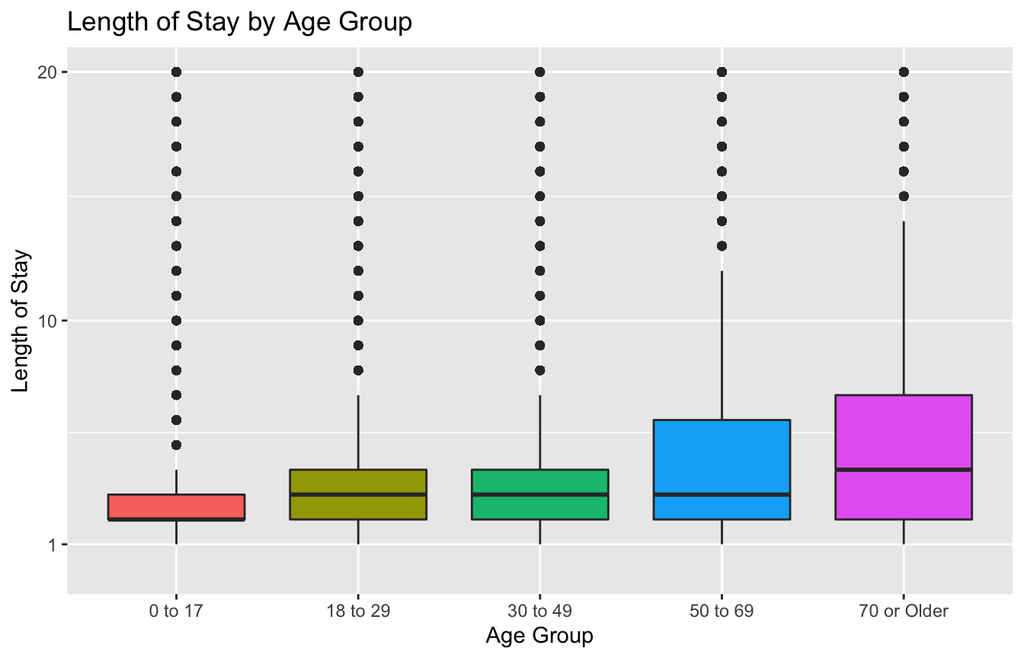

```r
ggplot(dat, aes(x = Age.Group, y = Length.of.Stay, fill = Age.Group)) + geom_boxplot() +
    theme(legend.position = "none") + ggtitle("Length of Stay by Age Group") + xlab("Age Group") +
    ylab("Length of Stay") + scale_y_continuous(breaks = c(1, 10, 20), limits = c(0,
    20))
```

### Avg LOS by MDC

The longest average length of stay among MDC groups was the 0 MDC group which corresponds to Pre-MDC or Ungroupable. As discussed earlier, the Pre-MDC group is primarily composed of transplant patients which explains the longer average time spent as an inpatient.

```r
report_plot(ggplot(dat, aes(x = APR.MDC.Code, y = Length.of.Stay, tooltip = APR.MDC.Description)) +
    geom_bar_interactive(stat = "summary", fun = "mean", fill = "#69b3a2") + ggtitle("Average Length of Stay by APR MDC Code") +
    xlab("APR MDC Code") + ylab("Average Length of Stay"))
```

[interactive chart not shown]

### Avg LOS by Severity

As severity of illness increases, average length of stay increases. Cases labeled as extreme stay for an average of 15 days.

```r
report_plot(ggplot(dat, aes(x = APR.Severity.of.Illness.Description, y = Length.of.Stay,
    fill = APR.Severity.of.Illness.Description)) + geom_bar_interactive(stat = "summary",
    fun = "mean") + theme(legend.position = "none") + ggtitle("Length of Stay by Severity of Illness") +
    xlab("Severity of Illness") + ylab("Average Length of Stay"))
```

[interactive chart not shown]

### LOS by Ownership

Ownership type was one of the variables merged from the second dataset which gave additional information about facility type. There is a clear distinction in mean length of stay between the different ownership types with the longest average length of stay being for a Public Benefit Corporation (PBC). A PBC is a type of for-profit entity. Municipality owned hospitals, which are run by the local government, have the second largest average length of stay

Similarly, the boxplot shows a higher median length of stay for PBC and a larger spread.

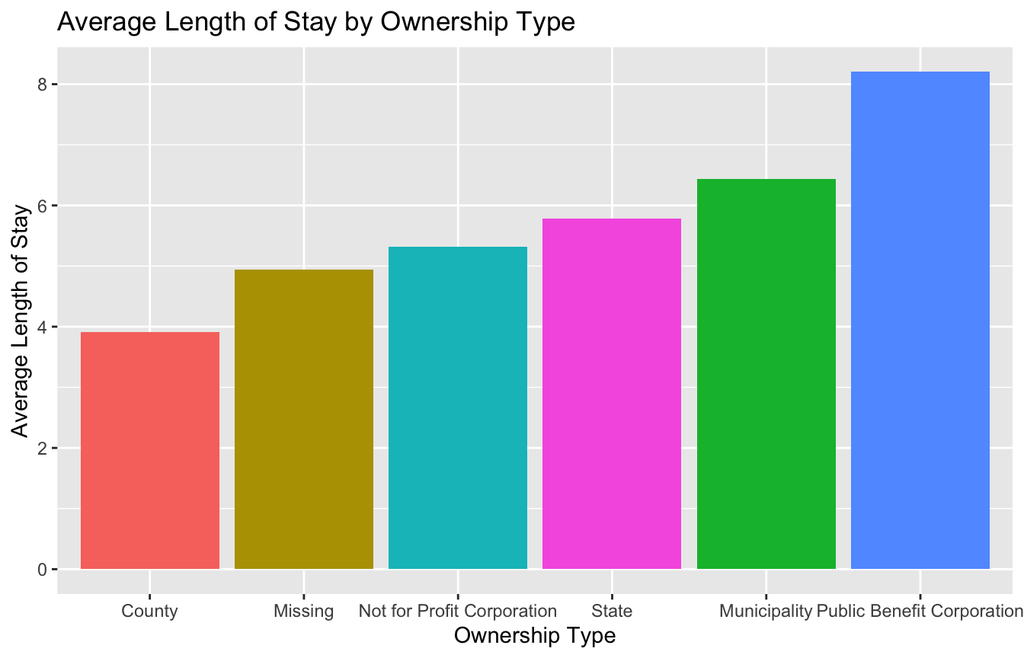

```r
ggplot(subset(dat, !is.na(Ownership.Type)), aes(x = reorder(Ownership.Type, Length.of.Stay),
    y = Length.of.Stay, fill = Ownership.Type)) + stat_summary(fun = "mean", geom = "bar") +
    theme(legend.position = "none") + ggtitle("Average Length of Stay by Ownership Type") +
    xlab("Ownership Type") + ylab("Average Length of Stay")
```

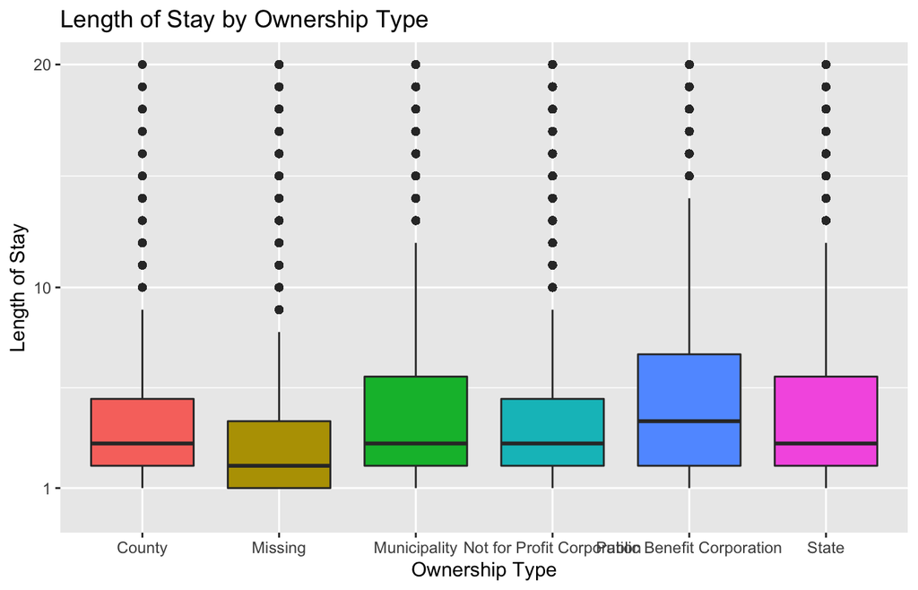

```r
ggplot(dat, aes(x = Ownership.Type, y = Length.of.Stay, fill = Ownership.Type)) +
    geom_boxplot() + theme(legend.position = "none") + ggtitle("Length of Stay by Ownership Type") +
    xlab("Ownership Type") + ylab("Length of Stay") + scale_y_continuous(breaks = c(1,
    10, 20), limits = c(0, 20))
```

### Avg LOS by Type

The average length of stay is greater in hospitals than in Critical Access Hospitals. Critical Access Hospitals are rural hospitals overseen by the Centers for Medicare and Medicaid Services (CMS) that meet the following criteria: 25 or fewer acute care inpatient beds, at least 35 miles from the nearest hospital, keep the average length of stay for the year at 96 hours or less for acute care patients, and have emergency care services available 24/7. By keeping their status as a Critical Access Hospital, they receive certain benefits from CMS which would Critical Access Hopsitals to keep the length of stay lower in order to keep their status. [10].

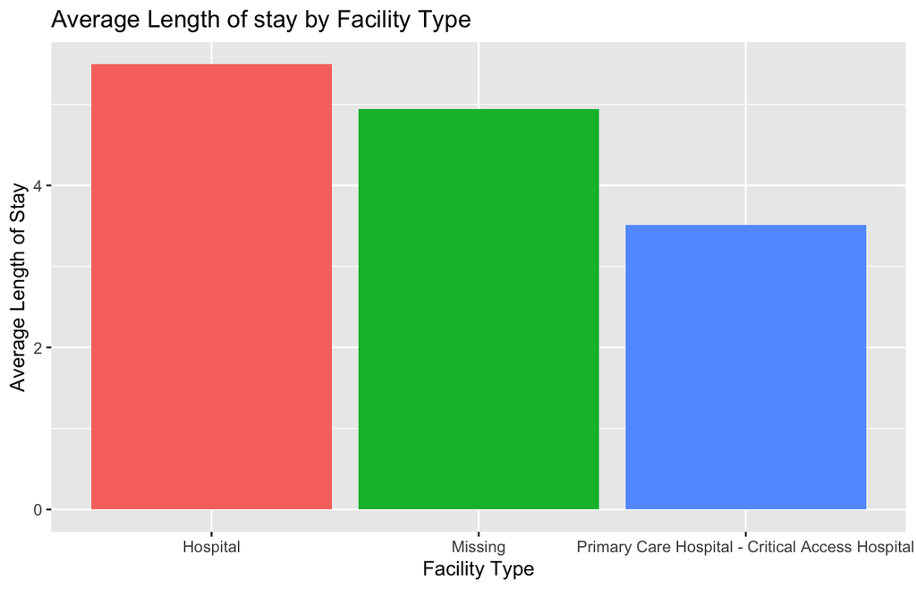

```r
ggplot(dat, aes(x = Facility.Type, y = Length.of.Stay, fill = Facility.Type)) + stat_summary(fun = "mean",
    geom = "bar") + theme(legend.position = "none") + ggtitle("Average Length of stay by Facility Type") +
    xlab("Facility Type") + ylab("Average Length of Stay")
```

## 3.3 CPD Figures

### Avg CPD by Admission

Cost per day is highest in patients with elective procedures and cases of trauma.

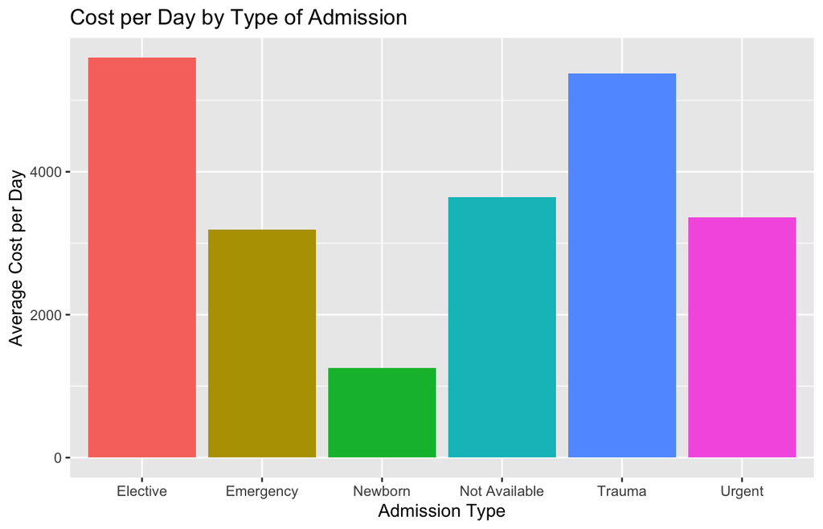

```r
ggplot(dat, aes(x = Type.of.Admission, y = Cost.per.Day, fill = Type.of.Admission)) +
    stat_summary(fun = "mean", geom = "bar") + theme(legend.position = "none") +
    ggtitle("Cost per Day by Type of Admission") + xlab("Admission Type") + ylab("Average Cost per Day")
```

### Avg CPD by Age

Average cost per day increased as age group increased with the highest average cost in the age group from 50 to 69. Surprisingly, average cost for those 70 or older was less than both age groups of 30 to 49 and 50 to 69.

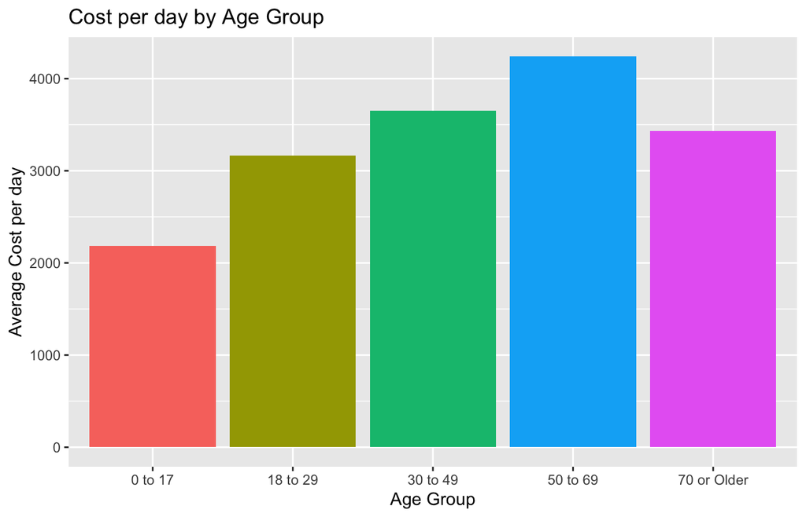

```r
ggplot(dat, aes(x = Age.Group, y = Cost.per.Day, fill = Age.Group)) + stat_summary(fun = "mean",
    geom = "bar") + theme(legend.position = "none") + ggtitle("Cost per day by Age Group") +
    xlab("Age Group") + ylab("Average Cost per day")
```

### Avg CPD by MDC

Diseases and Disorders of the Male Reproductive System (MDC Code 12), Diseases and Disorders of the Musculoskeletal System and Connective Tissue (MDC Code 8), Diseases and Disorders of the Female Reproductive System (MDC Code 13) had the highest average costs per day.

```r
report_plot(ggplot(dat, aes(x = APR.MDC.Code, y = Cost.per.Day, tooltip = APR.MDC.Description)) +
    geom_bar_interactive(stat = "summary", fun = "mean", fill = "#69b3a2") + ggtitle("Average Cost per day by APR MDC Code") +
    xlab("APR MDC Code") + ylab("Average Cost per day"))
```

[interactive chart not shown]

### Avg CPD by Ownership

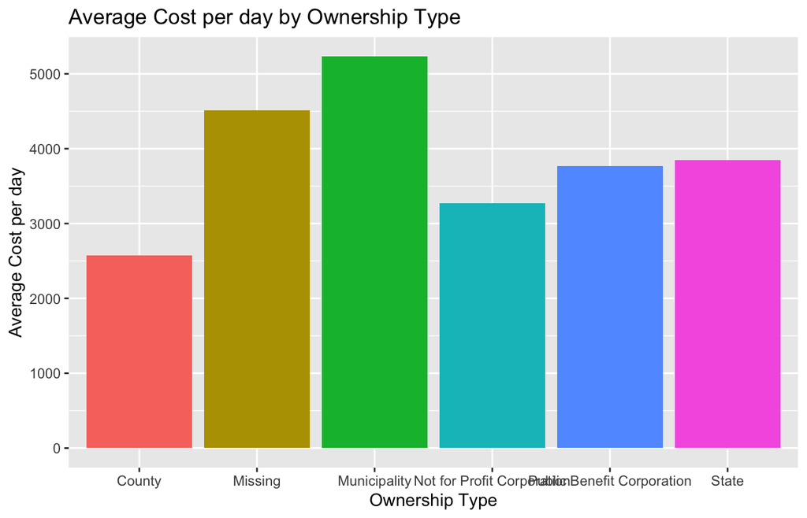

```r
ggplot(dat, aes(x = Ownership.Type, y = Cost.per.Day, fill = Ownership.Type)) + stat_summary(fun = "mean",
    geom = "bar") + theme(legend.position = "none") + ggtitle("Average Cost per day by Ownership Type") +
    xlab("Ownership Type") + ylab("Average Cost per day")
```

## 3.4 OBGYN/Neonate Data

The features of observations related to pregnancy and newborns/neonates have unique characteristics that differentiate them from the rest of the data.

### Birth Weight

We chose to filter out observations that were related to pregnancy and newborn data as there are unique characteristics of their features.

Birth weight was only reported for newborns and neonates. For all other observations, birth weight was recorded as 0.

In the figure below, we see that over 2 million observations have birth weight equal to 0.

```r
report_plot(ggplot(dat) + geom_histogram_interactive(aes(x = Birth.Weight, tooltip = ..count..),
    binwidth = 300, fill = "#69b3a2", color = "#e9ecef", alpha = 0.9) + ggtitle("Distribution of Birth Weight") +
    xlab("Birth Weight (grams)") + ylab("Frequency"))
```

[interactive chart not shown]

### Abortion Indicator

Due to confidentiality concerns, some columns were censored if the discharge record for that observation contained any potential indication of abortion, including but not limited to: elective abortion procedures, miscarriages, ectopic pregnancies, etc.

All observations with missing data for Facility.Id, Health Service Area, and Hospital County also had `Abortion.Edit.Indicator` = ‘Y’. The plot below shows the MDC codes that had observations where `Abortion.Edit.Indicator` was equal to ‘Y’. The majority of these observations were when `APR.MDC.Code` was equal to 14 which corresponds to the MDC ‘Pregnancy, Childbirth And Puerperium’.

```r
report_plot(ggplot(subset(dat, dat$Abortion.Edit.Indicator == "Y"), aes(x = APR.MDC.Code,
    tooltip = APR.MDC.Description)) + geom_bar_interactive(fill = "#69b3a2") + ggtitle("Frequency of Observations Related to Abortion by MDC Code") +
    xlab("APR MDC Code") + ylab("Frequency") + theme(legend.position = "none") +
    scale_y_continuous(labels = scales::comma))
```

[interactive chart not shown]

### Final Criteria

Rows meeting any of the following criteria were filtered:

- `APR.DRG.Code` corresponding to a `APR.DRG.Description` containing OB-GYN-related terms
- `CCS.Diagnosis.Code` corresponding to a `CCS.Diagnosis.Description` containing OB-GYN-related terms
- `APR.MDC.Code` = 14 [‘Pregnancy, Childbirth And Puerperium’]
- `APR.MDC.Code` = 15 [‘Newborn And Other Neonates (Perinatal Period)’]
- `Abortion.Edit.Indicator` = ‘Y’
- `Type.of.Admission` = ‘Newborn’
- `Birth.Weight` > 0

```r
# get unique codes, descriptions
aprdrg <- unique(dat[, c("APR.DRG.Code", "APR.DRG.Description")])
aprdrg <- aprdrg[order(aprdrg$APR.DRG.Code), ]
rownames(aprdrg) <- NULL

ccs <- unique(dat[, c("CCS.Diagnosis.Code", "CCS.Diagnosis.Description")])
ccs <- ccs[order(ccs$CCS.Diagnosis.Code), ]
rownames(ccs) <- NULL

# terms for filtering out OB-related
obgyn_terms <- paste0(c("abortion", "amniot", "birth", "C-section", "delivery", "fetal",
    "fetopelvic", "labor", "liveborn", "malposition", "natal", "neonat", "obstetric",
    "OB-related", "partum", "pregnancy", "umbilical cord complication"), collapse = "|")
exclude_terms <- paste0(c("non-obstetric", "except in labor"), collapse = "|")

filter_obgyn <- function(x) {
    return(grep(exclude_terms, grep(obgyn_terms, x, ignore.case = TRUE, value = TRUE),
        ignore.case = TRUE, value = TRUE, invert = TRUE))
}

# get APR.DRG.Code values to filter out
aprdrg_obgyn_codes <- aprdrg[aprdrg$APR.DRG.Description %in% filter_obgyn(aprdrg$APR.DRG.Description),
    "APR.DRG.Code"]

# get CCS.Diagnosis.Code values to filter out
ccs_obgyn_codes <- ccs[ccs$CCS.Diagnosis.Description %in% filter_obgyn(ccs$CCS.Diagnosis.Description),
    "CCS.Diagnosis.Code"]

# filter dat to include only non-obgyn data, non-neonate data
obgyn_rows <- with(dat, which(CCS.Diagnosis.Code %in% ccs_obgyn_codes | APR.DRG.Code %in%
    aprdrg_obgyn_codes | APR.MDC.Code == 14 | APR.MDC.Code == 15 | Abortion.Edit.Indicator ==
    "Y" | Type.of.Admission == "Newborn" | Birth.Weight > 0))
dat <- dat[-obgyn_rows, ]

# remove columns
dat <- dat[, which(!(colnames(dat) %in% c("Abortion.Edit.Indicator", "Birth.Weight")))]
```

# 4 Medicare Patient Data

Due to the amount of computing power that it would take to analyze the whole dataset, we chose to subset the data by if any of a patient’s payment types (primary, secondary, or tertiary) were Medicare. 874,388 patients had Medicare as their primary payment type, and 55,333 additional patients had Medicare as either their secondary or tertiary payment type for a total of 929,721 patients.

```r
# Subset to only medicare patients
medicare_rows <- with(dat, which(Payment.Typology.1 == "Medicare" | Payment.Typology.2 ==
    "Medicare" | Payment.Typology.3 == "Medicare"))
dat <- dat[medicare_rows, ]

# drop unused levels
dat <- droplevels(dat)
```

## 4.1 LOS Figures

### LOS

The distribution of length of stay in the subset with only patients with Medicare resembles the overall distribution, but the largest frequency of length of stay in this subset is 3 days.

```r
report_plot(ggplot(dat) + geom_histogram_interactive(aes(x = Length.of.Stay, tooltip = after_stat(count)),
    binwidth = 1, fill = "#69b3a2", color = "#e9ecef", alpha = 0.9) + ggtitle("Distribution of Length of Stay in Medicare Patients") +
    xlab("Length of Stay") + ylab("Frequency") + scale_x_continuous(breaks = c(1,
    10, 20, 30, 40), limits = c(0, 40)) + scale_y_continuous(labels = scales::comma))
```

[interactive chart not shown]

### MDC

The greatest number of medicare patients were admitted due to Diseases and Disorders of the Circulatory System (MDC Code 5) then Diseases and Disorders of the Respiratory System (MDC Code 4) and Diseases and Disorders of the Musculoskeletal System and Connective Tissue (MDC Code 8).

```r
report_plot(ggplot(dat, aes(x = APR.MDC.Code, tooltip = APR.MDC.Description)) + geom_bar_interactive(fill = "#69b3a2",
    color = "#e9ecef", alpha = 0.9) + ggtitle("APR MDC Code Frequency in Medicare Patients") +
    xlab("APR MDC Code") + ylab("Frequency"))
```

[interactive chart not shown]

### Age

As expected, the majority of patients with Medicare are 70 or older and also many in the 50 to 69 age group.

```r
report_plot(ggplot(dat, aes(x = Age.Group)) + geom_bar_interactive(aes(tooltip = after_stat(count)),
    fill = "#69b3a2", color = "#e9ecef", alpha = 0.9) + ggtitle("Age Group Frequency in Medicare Patients") +
    xlab("Medicare") + ylab("Frequency") + scale_y_continuous(labels = scales::comma))
```

[interactive chart not shown]

# 5 Analysis

```r
# Split train and test set
set.seed(123456)
train_rows <- caret::createDataPartition(y = dat$Length.of.Stay, p = 0.7, list = FALSE)
train <- dat[train_rows, ]
test <- dat[-train_rows, ]
```

## 5.1 Evaluation Metrics

We will be using the same evaluation metrics used in the literature for the assessment of similar length of stay prediction models: $R^2$ [1], mean absolute error (MAE) [1,2], mean relative error (MRE) [2], and root mean squared error (RMSE) [2].

$$MAE = \frac {\sum_{i = 1}^{n} |\hat y_i - y_i|}{n}$$

$$MRE = \frac {\sum_{i = 1}^{n} (|\hat y_i - y_i|/y_i)}{n}$$

$$RMSE = \sqrt\frac {\sum_{i = 1}^{n} (\hat y_i - y_i)^2}{n}$$
where $\hat y_i$ is the predicted value for length of stay or cost per dayand $y_i$ is the actual value for length of stay or cost per day.

```r
# Error functions
MAE <- function(pred, actual) {
    mean(abs(actual - pred))
}
MRE <- function(pred, actual) {
    mean(abs(actual - pred)/actual)
}
RMSE <- function(pred, actual) {
    sqrt(mean((actual - pred)^2))
}

evaluate_model <- function(model, test, response) {

    actual <- test[[response]]
    pred <- predict(model, test)

    # Remove rows when response == 0; MRE = infinity for those observations
    if (any(test[[response]] == 0)) {
        test_mre <- test[!test[[response]] == 0, ]
        pred_mre <- predict(model, test_mre)
        actual_mre <- test_mre[[response]]
    } else {
        pred_mre <- pred
        actual_mre <- actual
    }

    return(c(`Mean Absolute Error` = round(MAE(pred, actual), digits = 2), `Mean Relative Error` = round(MRE(pred_mre,
        actual_mre), digits = 2), `Root Mean Squared Error` = round(RMSE(pred, actual),
        digits = 2)))
}
```

## 5.2 Length of Stay

In the following models, we consider the following variables [4] to predict length of stay.

```r
report_table(data.frame(matrix(c("Age.Group", "Age in years at time of discharge grouped into 0 to 17, 18 to 29, 30 to 49, 50 to 69, 70+",
    "Gender", "Male, Female, Unknown", "Race", "Black/African American, Multi, Other Race, Unknown, White. ",
    "Ethnicity", "Spanish/Hispanic Origin, Not of Spanish/Hispanic Origin, Multi, Unknown.",
    "Type.of.Admission", "Elective, Emergency, Newborn, Not Available, Trauma, Urgent.",
    "APR.MDC.Code", "0-25", "APR.Severity.of.Illness.Code", "Minor (1), Moderate (2), Major (3) , Extreme (4). ",
    "APR.Risk.of.Mortality", "Minor (1), Moderate (2), Major (3) , Extreme (4).",
    "Ownership.Type", "County, Municipality, Not for Profit Corporation, Public Benefit Corporation, State",
    "Facility.Type", "Hospital, Primary Care Hospital - Critical Access Hospital",
    "Emergency.Department.Indicator", "If the record contained an Emergency Department revenue code of 045X, the indicator is set to \"Y\", otherwise it will be \"N\".",
    "Health.Service.Area", "8 service areas represented", "Hospital.County", "57 Hospital counties represented"),
    ncol = 2, byrow = TRUE, dimnames = list(NULL, c("Column", "Description")))))
```

| Column | Description |
| --- | --- |
| Age.Group | Age in years at time of discharge grouped into 0 to 17, 18 to 29, 30 to 49, 50 to 69, 70+ |
| Gender | Male, Female, Unknown |
| Race | Black/African American, Multi, Other Race, Unknown, White. |
| Ethnicity | Spanish/Hispanic Origin, Not of Spanish/Hispanic Origin, Multi, Unknown. |
| Type.of.Admission | Elective, Emergency, Newborn, Not Available, Trauma, Urgent. |
| APR.MDC.Code | 0-25 |
| APR.Severity.of.Illness.Code | Minor (1), Moderate (2), Major (3) , Extreme (4). |
| APR.Risk.of.Mortality | Minor (1), Moderate (2), Major (3) , Extreme (4). |
| Ownership.Type | County, Municipality, Not for Profit Corporation, Public Benefit Corporation, State |
| Facility.Type | Hospital, Primary Care Hospital - Critical Access Hospital |
| Emergency.Department.Indicator | If the record contained an Emergency Department revenue code of 045X, the indicator is set to “Y”, otherwise it will be “N”. |
| Health.Service.Area | 8 service areas represented |
| Hospital.County | 57 Hospital counties represented |

All of these variables are recorded at admission so no future information such as Total Cost is included in the model.

### 5.2.1 Linear Regression

We wanted to focus our efforts in predicting length of stay through regression methods and not classification methods because knowing the exact number of days a patient would need to stay would be overall more useful than knowing a range of days a patient may stay. We start with a simple linear regression as our base model although we acknowledge that fundamentally, this is not the proper model that we want to use to model length of stay.

```r
linearReg <- lm(Length.of.Stay ~ Age.Group + Gender + Race + Ethnicity + Type.of.Admission +
    APR.MDC.Code + APR.Severity.of.Illness.Code + APR.Risk.of.Mortality + Ownership.Type +
    Facility.Type + Emergency.Department.Indicator + Health.Service.Area + Hospital.County,
    data = train)

R2_linreg_los <- round(summary(linearReg)$r.squared, 4)

# Evaluate linear regression model
eval_LOS_linear <- evaluate_model(linearReg, test, "Length.of.Stay")

# print model summary
summary(linearReg)
```

```
##
## Call:
## lm(formula = Length.of.Stay ~ Age.Group + Gender + Race + Ethnicity +
##     Type.of.Admission + APR.MDC.Code + APR.Severity.of.Illness.Code +
##     APR.Risk.of.Mortality + Ownership.Type + Facility.Type +
##     Emergency.Department.Indicator + Health.Service.Area + Hospital.County,
##     data = train)
##
## Residuals:
##     Min      1Q  Median      3Q     Max
## -24.335  -2.927  -0.986   1.355 119.049
##
## Coefficients: (8 not defined because of singularities)
##                                                                Estimate
## (Intercept)                                                    1.582968
## Age.Group18 to 29                                              2.009829
## Age.Group30 to 49                                              1.992903
## Age.Group50 to 69                                              2.065473
## Age.Group70 or Older                                           1.646227
## GenderM                                                       -0.045665
## GenderU                                                       -4.038436
## RaceMulti-racial                                              -0.210367
## RaceOther Race                                                -0.499397
## RaceWhite                                                     -0.397459
## EthnicityNot Span/Hispanic                                     0.260817
## EthnicitySpanish/Hispanic                                     -0.061802
## EthnicityUnknown                                               0.249204
## Type.of.AdmissionEmergency                                    -0.664516
## Type.of.AdmissionNot Available                                -1.049365
## Type.of.AdmissionTrauma                                       -0.169347
## Type.of.AdmissionUrgent                                        0.769172
## APR.MDC.Code2                                                 -0.812950
## APR.MDC.Code3                                                 -0.984792
## APR.MDC.Code4                                                 -0.616304
## APR.MDC.Code5                                                 -1.101961
## APR.MDC.Code6                                                 -0.049095
## APR.MDC.Code7                                                 -0.275372
## APR.MDC.Code8                                                 -0.071825
## APR.MDC.Code9                                                  0.078683
## APR.MDC.Code10                                                -1.213670
```

[output cut: 432 more lines]

```
## Hospital.CountySuffolk
## Hospital.CountySullivan                                       ***
## Hospital.CountyTompkins
## Hospital.CountyUlster                                         ***
## Hospital.CountyWarren                                         ***
## Hospital.CountyWayne                                          **
## Hospital.CountyWestchester
## Hospital.CountyWyoming
## Hospital.CountyYates
## ---
## Signif. codes:  0 '***' 0.001 '**' 0.01 '*' 0.05 '.' 0.1 ' ' 1
##
## Residual standard error: 7.378 on 650698 degrees of freedom
## Multiple R-squared:  0.2078, Adjusted R-squared:  0.2077
## F-statistic:  1595 on 107 and 650698 DF,  p-value: < 2.2e-16
```

The $R^2$ value for the simple linear regression on the training data is 0.2078.

### 5.2.2 Poisson Model

When you look at thet possible values of length of stay, you see that length of stay can only be integer values greater than 1. Linear regression, on the other hand, will give you continuous values from -infinty to infinity. Therefore, our next step was to model length of stay as a Poisson regression which models count data. This still isn’t quite the right model as a normal Poisson can take on values of 0. Since this is inpatient data, there will never be a patient who has a length of stay of 0.

```r
Poi <- glm(Length.of.Stay ~ Age.Group + Gender + Race + Ethnicity + Type.of.Admission +
    APR.MDC.Code + APR.Severity.of.Illness.Code + APR.Risk.of.Mortality + Ownership.Type +
    Facility.Type + Emergency.Department.Indicator + Health.Service.Area + Hospital.County,
    family = Poisson(link = "log"), data = train)

# Evaluate Poisson model
eval_LOS_Poi <- evaluate_model(Poi, test, "Length.of.Stay")

# print model summary
summary(Poi)
```

```
##
## Call:
## glm(formula = Length.of.Stay ~ Age.Group + Gender + Race + Ethnicity +
##     Type.of.Admission + APR.MDC.Code + APR.Severity.of.Illness.Code +
##     APR.Risk.of.Mortality + Ownership.Type + Facility.Type +
##     Emergency.Department.Indicator + Health.Service.Area + Hospital.County,
##     family = Poisson(link = "log"), data = train)
##
## Deviance Residuals:
##     Min       1Q   Median       3Q      Max
## -9.9756  -1.3767  -0.5129   0.5440  26.0797
##
## Coefficients: (8 not defined because of singularities)
##                                                                 Estimate
## (Intercept)                                                    6.450e-01
## Age.Group18 to 29                                              5.063e-01
## Age.Group30 to 49                                              4.843e-01
## Age.Group50 to 69                                              4.657e-01
## Age.Group70 or Older                                           3.969e-01
## GenderM                                                       -6.463e-03
## GenderU                                                       -7.226e-01
## RaceMulti-racial                                              -3.176e-02
## RaceOther Race                                                -7.386e-02
## RaceWhite                                                     -5.785e-02
## EthnicityNot Span/Hispanic                                     4.397e-02
## EthnicitySpanish/Hispanic                                     -4.028e-03
## EthnicityUnknown                                               4.202e-02
## Type.of.AdmissionEmergency                                    -1.135e-01
## Type.of.AdmissionNot Available                                -1.600e-01
## Type.of.AdmissionTrauma                                       -3.757e-02
## Type.of.AdmissionUrgent                                        7.539e-02
## APR.MDC.Code2                                                 -1.602e-01
## APR.MDC.Code3                                                 -1.882e-01
## APR.MDC.Code4                                                 -8.969e-02
## APR.MDC.Code5                                                 -1.808e-01
## APR.MDC.Code6                                                 -7.268e-03
## APR.MDC.Code7                                                 -4.704e-02
## APR.MDC.Code8                                                 -1.727e-05
## APR.MDC.Code9                                                  2.144e-02
## APR.MDC.Code10                                                -2.106e-01
```

[output cut: 436 more lines]

```
## Hospital.CountyWarren                                         ***
## Hospital.CountyWayne                                          ***
## Hospital.CountyWestchester
## Hospital.CountyWyoming
## Hospital.CountyYates
## ---
## Signif. codes:  0 '***' 0.001 '**' 0.01 '*' 0.05 '.' 0.1 ' ' 1
##
## (Dispersion parameter for poisson family taken to be 1)
##
##     Null deviance: 3810956  on 650805  degrees of freedom
## Residual deviance: 2576837  on 650698  degrees of freedom
## AIC: 4767737
##
## Number of Fisher Scoring iterations: 5
```

Note, the same hospital county coefficients were not estimated in using the Poisson model either.

### 5.2.3 Zero-Truncated Poisson Model

Next we look at the Zero-Truncated Poisson model. This is a modification of the Poisson model, and it can only take integer values from 1 to infinity. Therfore, this model is more appropriate to model length of stay because it will never take 0 values.

```r
# GLM with zero-truncated Poisson
ZeroTruncated_Poi <- glm(Length.of.Stay ~ Age.Group + Gender + Race + Ethnicity +
    Type.of.Admission + APR.MDC.Code + APR.Severity.of.Illness.Code + APR.Risk.of.Mortality +
    Ownership.Type + Facility.Type + Emergency.Department.Indicator + Health.Service.Area +
    Hospital.County, family = Tpoisson(link = "log"), data = train)

# Evaluate Zero-Truncated Poisson model
eval_LOS_ZeroTruncPoi <- evaluate_model(ZeroTruncated_Poi, test, "Length.of.Stay")

# print model summary
summary(ZeroTruncated_Poi)
```

```
##
## Call:
## glm(formula = Length.of.Stay ~ Age.Group + Gender + Race + Ethnicity +
##     Type.of.Admission + APR.MDC.Code + APR.Severity.of.Illness.Code +
##     APR.Risk.of.Mortality + Ownership.Type + Facility.Type +
##     Emergency.Department.Indicator + Health.Service.Area + Hospital.County,
##     family = Tpoisson(link = "log"), data = train)
##
## Deviance Residuals:
##     Min       1Q   Median       3Q      Max
## -9.9902  -1.4900  -0.5611   0.5219  26.0771
##
## Coefficients: (8 not defined because of singularities)
##                                                                 Estimate
## (Intercept)                                                    6.450e-01
## Age.Group18 to 29                                              5.063e-01
## Age.Group30 to 49                                              4.843e-01
## Age.Group50 to 69                                              4.657e-01
## Age.Group70 or Older                                           3.969e-01
## GenderM                                                       -6.463e-03
## GenderU                                                       -7.226e-01
## RaceMulti-racial                                              -3.176e-02
## RaceOther Race                                                -7.386e-02
## RaceWhite                                                     -5.785e-02
## EthnicityNot Span/Hispanic                                     4.397e-02
## EthnicitySpanish/Hispanic                                     -4.028e-03
## EthnicityUnknown                                               4.202e-02
## Type.of.AdmissionEmergency                                    -1.135e-01
## Type.of.AdmissionNot Available                                -1.600e-01
## Type.of.AdmissionTrauma                                       -3.757e-02
## Type.of.AdmissionUrgent                                        7.539e-02
## APR.MDC.Code2                                                 -1.602e-01
## APR.MDC.Code3                                                 -1.882e-01
## APR.MDC.Code4                                                 -8.969e-02
## APR.MDC.Code5                                                 -1.808e-01
## APR.MDC.Code6                                                 -7.268e-03
## APR.MDC.Code7                                                 -4.704e-02
## APR.MDC.Code8                                                 -1.727e-05
## APR.MDC.Code9                                                  2.144e-02
## APR.MDC.Code10                                                -2.106e-01
```

[output cut: 436 more lines]

```
## Hospital.CountyWarren                                         ***
## Hospital.CountyWayne                                          ***
## Hospital.CountyWestchester
## Hospital.CountyWyoming
## Hospital.CountyYates
## ---
## Signif. codes:  0 '***' 0.001 '**' 0.01 '*' 0.05 '.' 0.1 ' ' 1
##
## (Dispersion parameter for poisson family taken to be 1)
##
##     Null deviance: 3918426  on 650805  degrees of freedom
## Residual deviance: 2668093  on 650698  degrees of freedom
## AIC: 4749735
##
## Number of Fisher Scoring iterations: 5
```

### 5.2.4 Hierarchical Zero-Truncated Poisson Model

Lastly, we fit a hierarchical zero-truncted poisson model. If you look at the variables for Health Serivce Area and Hospital County, you can see that these are nested varaibles. For example, specific hospital counties will only occur in specific health areas. By modeling length of stay as a multi-level model, we can take into account the area-level and county-level effects on length of stay by accounting for unexplained variation in hospital service areas and hospital counties.

```r
# GLM with zero-truncated Poisson, nesting
Hierarchical_LOS <- HLfit(Length.of.Stay ~ Age.Group + Gender + Race + Ethnicity +
    Type.of.Admission + APR.MDC.Code + APR.Severity.of.Illness.Code + APR.Risk.of.Mortality +
    Ownership.Type + Emergency.Department.Indicator + (1 | Hospital.County/Health.Service.Area),
    family = Tpoisson(link = "log"), data = train)

# Evaluate Hierarchical LOS model
eval_LOS_Hier <- evaluate_model(Hierarchical_LOS, test, "Length.of.Stay")

# print model summary
summary(Hierarchical_LOS, details = TRUE, max.print = 99999999)
```

```
## formula: Length.of.Stay ~ Age.Group + Gender + Race + Ethnicity + Type.of.Admission +
##     APR.MDC.Code + APR.Severity.of.Illness.Code + APR.Risk.of.Mortality +
##     Ownership.Type + Emergency.Department.Indicator + (1 | Hospital.County/Health.Service.Area)
## Estimation of lambda by Laplace REML approximation (p_bv).
## Estimation of fixed effects by Laplace ML approximation (p_v).
## Family: 0-truncated poisson ( link = log )
##  ------------ Fixed effects (beta) ------------
##                                           Estimate Cond. SE   t-value
## (Intercept)                               0.670052 0.091883    7.2925
## Age.Group18 to 29                         0.563637 0.033128   17.0141
## Age.Group30 to 49                         0.539738 0.032829   16.4411
## Age.Group50 to 69                         0.518193 0.032780   15.8081
## Age.Group70 or Older                      0.446854 0.032782   13.6313
## GenderM                                  -0.006656 0.000996   -6.6830
## GenderU                                  -0.778943 0.223109   -3.4913
## RaceMulti-racial                         -0.032731 0.005590   -5.8557
## RaceOther Race                           -0.075834 0.001849  -41.0242
## RaceWhite                                -0.059199 0.001444  -41.0040
## EthnicityNot Span/Hispanic                0.045120 0.010731    4.2045
## EthnicitySpanish/Hispanic                -0.004238 0.010868   -0.3900
## EthnicityUnknown                          0.043643 0.011051    3.9493
## Type.of.AdmissionEmergency               -0.118570 0.002326  -50.9837
## Type.of.AdmissionNot Available           -0.166401 0.021303   -7.8111
## Type.of.AdmissionTrauma                  -0.040238 0.009972   -4.0352
## Type.of.AdmissionUrgent                   0.074907 0.002403   31.1787
## APR.MDC.Code2                            -0.169620 0.017190   -9.8671
## APR.MDC.Code3                            -0.198829 0.005826  -34.1282
## APR.MDC.Code4                            -0.092312 0.002304  -40.0607
## APR.MDC.Code5                            -0.187561 0.002159  -86.8871
## APR.MDC.Code6                            -0.007507 0.002407   -3.1188
## APR.MDC.Code7                            -0.049165 0.003539  -13.8930
## APR.MDC.Code8                             0.001406 0.002479    0.5674
## APR.MDC.Code9                             0.022725 0.003634    6.2539
## APR.MDC.Code10                           -0.219294 0.003647  -60.1227
## APR.MDC.Code11                           -0.145817 0.002644  -55.1457
## APR.MDC.Code12                           -0.224910 0.008743  -25.7254
## APR.MDC.Code13                           -0.124747 0.007744  -16.1087
## APR.MDC.Code16                           -0.113621 0.004673  -24.3122
## APR.MDC.Code17                            0.241778 0.004495   53.7928
## APR.MDC.Code18                           -0.081043 0.002305  -35.1526
```

[output cut: 19 more lines]

```
##  --------------- Random effects ---------------
## Family: gaussian ( link = identity )
##            --- Variance parameters ('lambda'):
## lambda = var(u) for u ~ Gaussian;
##    Health.Se.  :  0.01527
##    Hospital..  :  0.01527
##              --- Coefficients for log(lambda):
##       Group        Term Estimate Cond.SE
##  Health.Se. (Intercept)   -4.182  0.2694
##  Hospital.. (Intercept)   -4.182  0.2694
## # of obs: 650806; # of groups: Health.Se., 57; Hospital.., 57
##  ------------- Likelihood values  -------------
##                        logLik
## p_v(h) (marginal L): -2374541
##   p_beta,v(h) (ReL): -2374776
```

### 5.2.5 Model Comparison

```r
LOS_compare <- cbind(`Linear Regression` = eval_LOS_linear, `Poisson Model` = eval_LOS_Poi,
    `ZTPoisson Model` = eval_LOS_ZeroTruncPoi, `Hierarchical ZTPoisson` = eval_LOS_Hier)

# Print table
report_table(LOS_compare, rownames = TRUE, scroll = FALSE)
```

|  | Linear Regression | Poisson Model | ZTPoisson Model | Hierarchical ZTPoisson |
| --- | --- | --- | --- | --- |
| Mean Absolute Error | 3.90 | 4.95 | 4.95 | 3.86 |
| Mean Relative Error | 1.02 | 0.60 | 0.60 | 1.01 |
| Root Mean Squared Error | 7.35 | 9.39 | 9.39 | 7.34 |

## 5.3 Cost per Day

### 5.3.1 Linear Regression

In predicting cost per day, we focused on comparing simple linear regression results to the results for a hierarchical linear model accounting for the variance in serivce area and hospital county. We predicted that we would see an improvement in performance by using a more complicated and computationally heavy approach using the hierarchical structure since it would account for the structure of the data.

```r
# Linear regression for cost per day
linearReg_Cost <- lm(Cost.per.Day ~ Age.Group + Gender + Race + Ethnicity + Type.of.Admission +
    APR.MDC.Code + APR.Severity.of.Illness.Code + APR.Risk.of.Mortality + Ownership.Type +
    Facility.Type + Emergency.Department.Indicator + Health.Service.Area + Hospital.County,
    data = train)

# Evaluate Linear regression cost per day model
eval_Cost_linear <- evaluate_model(linearReg_Cost, test, "Cost.per.Day")

R2_linreg_cpd <- round(summary(linearReg_Cost)$r.squared, 4)

# print model summary
summary(linearReg_Cost)
```

```
##
## Call:
## lm(formula = Cost.per.Day ~ Age.Group + Gender + Race + Ethnicity +
##     Type.of.Admission + APR.MDC.Code + APR.Severity.of.Illness.Code +
##     APR.Risk.of.Mortality + Ownership.Type + Facility.Type +
##     Emergency.Department.Indicator + Health.Service.Area + Hospital.County,
##     data = train)
##
## Residuals:
##    Min     1Q Median     3Q    Max
##  -8806  -1315   -368    586 959967
##
## Coefficients: (8 not defined because of singularities)
##                                                                 Estimate
## (Intercept)                                                    3.144e+03
## Age.Group18 to 29                                              4.262e+02
## Age.Group30 to 49                                              4.106e+02
## Age.Group50 to 69                                              5.347e+02
## Age.Group70 or Older                                           2.949e+02
## GenderM                                                        2.450e+02
## GenderU                                                        1.192e+02
## RaceMulti-racial                                               8.979e+02
## RaceOther Race                                                 5.409e+02
## RaceWhite                                                      2.293e+02
## EthnicityNot Span/Hispanic                                     1.832e+02
## EthnicitySpanish/Hispanic                                      1.347e+02
## EthnicityUnknown                                               2.286e+02
## Type.of.AdmissionEmergency                                    -2.595e+03
## Type.of.AdmissionNot Available                                -1.662e+03
## Type.of.AdmissionTrauma                                       -1.252e+03
## Type.of.AdmissionUrgent                                       -2.102e+03
## APR.MDC.Code2                                                 -2.662e+02
## APR.MDC.Code3                                                 -4.999e+02
## APR.MDC.Code4                                                 -4.682e+02
## APR.MDC.Code5                                                  9.317e+02
## APR.MDC.Code6                                                 -5.717e+02
## APR.MDC.Code7                                                 -3.830e+02
## APR.MDC.Code8                                                  5.136e+02
## APR.MDC.Code9                                                 -7.349e+02
## APR.MDC.Code10                                                -4.322e+02
```

[output cut: 432 more lines]

```
## Hospital.CountySuffolk
## Hospital.CountySullivan                                       ***
## Hospital.CountyTompkins
## Hospital.CountyUlster                                         ***
## Hospital.CountyWarren                                         ***
## Hospital.CountyWayne                                          .
## Hospital.CountyWestchester
## Hospital.CountyWyoming
## Hospital.CountyYates
## ---
## Signif. codes:  0 '***' 0.001 '**' 0.01 '*' 0.05 '.' 0.1 ' ' 1
##
## Residual standard error: 3890 on 650698 degrees of freedom
## Multiple R-squared:  0.1971, Adjusted R-squared:  0.197
## F-statistic:  1493 on 107 and 650698 DF,  p-value: < 2.2e-16
```

### 5.3.2 Hierarchical Linear Regression

```r
Hierarchical_cost <- lmer(Cost.per.Day ~ Age.Group + Gender + Race + Ethnicity +
    Type.of.Admission + APR.MDC.Code + APR.Severity.of.Illness.Code + APR.Risk.of.Mortality +
    Ownership.Type + Facility.Type + Emergency.Department.Indicator + (1 | Hospital.County/Health.Service.Area),
    data = train)

# Evaluation Hierarchical model for cost per day
eval_Cost_Hier <- evaluate_model(Hierarchical_cost, test, "Cost.per.Day")

# print model summary
summary(Hierarchical_cost)
```

```
## Linear mixed model fit by REML ['lmerMod']
## Formula:
## Cost.per.Day ~ Age.Group + Gender + Race + Ethnicity + Type.of.Admission +
##     APR.MDC.Code + APR.Severity.of.Illness.Code + APR.Risk.of.Mortality +
##     Ownership.Type + Facility.Type + Emergency.Department.Indicator +
##     (1 | Hospital.County/Health.Service.Area)
##    Data: train
##
## REML criterion at convergence: 12606082
##
## Scaled residuals:
##     Min      1Q  Median      3Q     Max
##  -2.259  -0.338  -0.094   0.150 246.767
##
## Random effects:
##  Groups                              Name        Variance Std.Dev.
##  Health.Service.Area:Hospital.County (Intercept)   125280  353.9
##  Hospital.County                     (Intercept)   478652  691.8
##  Residual                                        15134035 3890.2
## Number of obs: 650806, groups:
## Health.Service.Area:Hospital.County, 57; Hospital.County, 57
##
## Fixed effects:
##                                                                Estimate
## (Intercept)                                                    5250.009
## Age.Group18 to 29                                               424.185
## Age.Group30 to 49                                               408.587
## Age.Group50 to 69                                               532.686
## Age.Group70 or Older                                            292.687
## GenderM                                                         245.032
## GenderU                                                         119.851
## RaceMulti-racial                                                899.269
## RaceOther Race                                                  541.139
## RaceWhite                                                       228.700
## EthnicityNot Span/Hispanic                                      197.807
## EthnicitySpanish/Hispanic                                       149.226
## EthnicityUnknown                                                241.076
## Type.of.AdmissionEmergency                                    -2596.827
## Type.of.AdmissionNot Available                                -1664.401
## Type.of.AdmissionTrauma                                       -1251.122
```

[output cut: 131 more lines]

```
## APR.Severity.of.Illness.Code4                                   -5.441
## APR.Risk.of.MortalityMajor                                     -12.832
## APR.Risk.of.MortalityMinor                                       2.800
## APR.Risk.of.MortalityModerate                                   -6.562
## Ownership.TypeMissing                                            5.811
## Ownership.TypeMunicipality                                       5.659
## Ownership.TypeNot for Profit Corporation                         0.141
## Ownership.TypePublic Benefit Corporation                         1.801
## Ownership.TypeState                                              2.195
## Facility.TypePrimary Care Hospital - Critical Access Hospital    1.556
## Emergency.Department.IndicatorY                                -40.554
## fit warnings:
## fixed-effect model matrix is rank deficient so dropping 1 column / coefficient
## optimizer (nloptwrap) convergence code: 0 (OK)
## Model failed to converge with max|grad| = 0.00304176 (tol = 0.002, component 1)
```

### 5.3.3 Model Comparison

```r
CPD_compare = cbind(`Linear Regression` = eval_Cost_linear, `Hierarchical Linear Regression` = eval_Cost_Hier)

# Print table
report_table(CPD_compare, rownames = TRUE, scroll = FALSE)
```

|  | Linear Regression | Hierarchical Linear Regression |
| --- | --- | --- |
| Mean Absolute Error | 1620.99 | 1620.82 |
| Mean Relative Error | 1.69 | 1.69 |
| Root Mean Squared Error | 3468.36 | 3468.38 |

# 6 Discussion

We did not see a large increase in predictive power as we expected by using the hierarchical linear model in either of the two predictions. The evaluation metrics between the two methods are very similar indicating that there wasn’t much to gain in performance by using the more computationally intensive method.However, the reward you do get for running the hierarchical model is that it better represents the structure of the data, and it knows how to treat the nested variables. Since linear regression does not have the knowledge of the correlation between the nested variables, it ends up not being able to estimate certain coefficients and you get the warning “prediction from a rank-deficient fit may be misleading” when trying to predict using the linear regression model. Thus, it is better to take into account the hierarchical structure of the results to be able to trust the results of your predictions.

If we wanted to use a model to predict length of stay, in practice we don’t want the model to predict -1.5 because that would not be a realistic prediction. At least, by using a zero-truncated poisson for predicting length of stay, we are taking into account that the predicted value should be at least 1.

For the cost per day analysis, we believe we may not have seen much of a difference between the two techniques because there is likely not much difference in cost between hospitals, especially between hospitals in the same general area.

One limitation of this analysis is that we only have inpatient discharge data, and thus we do not have information about patients who were admitted but later died. It would be interesting to consider these patients as well in our analysis as it would likely have an impact on the distribution of length of stay. It also would have been interesting to have more information about past medical history of the patients as that information would likely be correlated with length of stay. The lack of computing power available was also a limitation of the analysis. We did not incorporate Facility.ID as one of the nested variables because there were 211 distinct facilities to estimate. If we had more computing power, we could have included more variables and observations in our analysis.

# Bibliography

[1] W.M. Tierney, J.F. Fitzgerald, M.E. Miller, M.K. James, C.J. McDonald, Predicting inpatient costs with admitting clinical data, Med Care. 33 (1995) 1–14. https://doi.org/10.1097/00005650-199501000-00001.

[2] P.-F. Tsai, P.-C. Chen, Y.-Y. Chen, H.-Y. Song, H.-M. Lin, F.-M. Lin, Q.-P. Huang, Length of Hospital Stay Prediction at the Admission Stage for Cardiology Patients Using Artificial Neural Network, Journal of Healthcare Engineering. 2016 (2016) e7035463. https://doi.org/http://dx.doi.org/10.1155/2016/7035463.

[3] C. Yang, C. Delcher, E. Shenkman, S. Ranka, Machine learning approaches for predicting high cost high need patient expenditures in health care, BioMedical Engineering OnLine. 17 (2018) 131. https://doi.org/10.1186/s12938-018-0568-3.

[4] New York State Department of Health, The Statewide Planning and Research Cooperative System (SPARCS) Inpatient De-identified File, 2017. https://health.data.ny.gov/Health/Hospital-Inpatient-Discharges-SPARCS-De-Identified/82xm-y6g8 (accessed November 3, 2020).

[5] J. Almeida, 2015 de-identified NY inpatient discharge (SPARCS), 2018. https://kaggle.com/jonasalmeida/2015-deidentified-ny-inpatient-discharge-sparcs (accessed November 3, 2020).

[6] OECD, Average length of stay in hospitals, in: Health at a Glance 2011: OECD Indicators, OECD Publishing, Paris, 2011: pp. 88–89. https://www.oecd-ilibrary.org/social-issues-migration-health/health-at-a-glance-2011/average-length-of-stay-in-hospitals_health_glance-2011-33-en (accessed November 3, 2020).

[7] G.H. Robinson, L.E. Davis, R.P. Leifer, Prediction of Hospital Length of Stay, Health Serv Res. 1 (1966) 287–300. https://www.ncbi.nlm.nih.gov/pmc/articles/PMC1067345/ (accessed November 3, 2020).

[8] New York State Department of Health, Health Facility General Information, 2014. https://health.data.ny.gov/Health/Health-Facility-General-Information/vn5v-hh5r (accessed December 5, 2020).

[9] Centers for Medicare & Medicaid Services, ICD-10-CM/PCS MS-DRG v38.0 Definitions Manual, Centers for Medicare & Medicaid Services, Baltimore, MD, 2020. https://www.cms.gov/icd10m/version38-fullcode-cms/fullcode_cms/P0001.html (accessed December 5, 2020).

[10] Rural Health Information Hub, Critical Access Hospitals (CAHs), (2019). https://www.ruralhealthinfo.org/topics/critical-access-hospitals (accessed December 5, 2020).